# Code Document: Redistributive preferences in unequal contexts

Gonzalo Franetovic

18-11-2018

The research code document is detailed below. The adjustment of the databases, cleaning and recoding of variables, estimation of models, tables and graphic figures are explained step by step. Other analyzes available in the document “Code annex”.

- Install work packages
- Full LAPOP database paid for by the Institute of Political Science of the Pontificia Universidad Católica de Chile (incorporates information omitted in the free version)

```r
#Directory and databases
lapop <- read_dta("Databases/OriginalLapop/Lapop_full_reduced.dta")
lapop=as.data.frame(lapop) #Transformation to Data Frame
names(lapop)= tolower(names(lapop)) #Name of the variables in minuscule

#Name of the variables
lapop=lapop %>% dplyr::select(pais, year, idnum, weight1500, wt, ros4, q1, q2, q11, q11n, l1, ocup4a, ed, q10, q10new, ur, tamano, b12, b18, b10a, b21a, b13, b21, q12)
colnames(lapop) <- c("country","year", "id", "weight1500", "wt", "redistribution", "man", "age", "married1", "married2", "ideology", "employment", "education", "income1", "income2", "zone", "sizecity", "ffaaconfidence", "policeconfidence", "judicialconfidence", "executiveconfidence", "congressconfidence", "polpartiesconfidence", "children")

#Adjustment of different variables between years
#Married
lapop$married1[is.na(lapop$married1)] <- 99
lapop$married2[is.na(lapop$married2)] <- 99
lapop$married <- (lapop$married1+lapop$married2)-99
lapop$married1 <-NULL
lapop$married2 <-NULL
#Income
lapop$income1[is.na(lapop$income1)] <- 99
lapop$income2[is.na(lapop$income2)] <- 99
lapop$income <- (lapop$income1 + lapop$income2)-99
lapop$income[lapop$income==99] <- NA
lapop$income1 <-NULL
lapop$income2 <-NULL
```

- Selection and identification of the countries and waves of the sample

```r
#Remove countries that we will not consider in the sample
lapop$country <- as.numeric(lapop$country)
lapop<-lapop[!(lapop$country>21),]
lapop$country[lapop$country==21] <- "18"
#Countries of the sample (Labels)
lapop$country <- factor(lapop$country,
levels = c(1,2,3,4,5,6,7,8,9,10,11,12,13,14,15,16,17,18),
labels = c("MEX", "GTM", "SLV", "HND", "NIC", "CRI", "PAN", "COL", "ECU", "BOL", "PER", "PRY", "CHL", "URY", "BRA", "VEN", "ARG", "DOM"))
lapop$countryname <- countrycode(lapop$country,'iso3c','country.name')
#Remove waves that we will not consider in the sample
lapop<-lapop[!(lapop$year<2008),]
describe(lapop$country)
```

```
## lapop$country
##        n  missing distinct
##   119718        0       18
##
## Value        MEX   GTM   SLV   HND   NIC   CRI   PAN   COL   ECU   BOL
## Frequency   6217  6047  6108  6407  6311  6034  6200  6017  8988 12116
## Proportion 0.052 0.051 0.051 0.054 0.053 0.050 0.052 0.050 0.075 0.101
##
## Value        PER   PRY   CHL   URY   BRA   VEN   ARG   DOM
## Frequency   6000  5680  6634  6024  6978  6000  5920  6037
## Proportion 0.050 0.047 0.055 0.050 0.058 0.050 0.049 0.050
```

```r
describe(lapop$year)
```

```
## lapop$year
##        n  missing distinct     Info     Mean      Gmd
##   119718        0        4    0.937     2011    2.481
##
## Value       2008  2010  2012  2014
## Frequency  29932 31657 29255 28874
## Proportion 0.250 0.264 0.244 0.241
```

- Individual level variables

```r
#Waves:
lapop$wave <- lapop$year
lapop$wave=rec(lapop$wave, rec=c("2008=08", "2010=10", "2012=12", "2014=14"))
lapop$year = as.factor(lapop$year)
#Country_year:
lapop$country_wave <- do.call(paste, c(lapop[c("country", "wave")], sep = "_"))

#Redistribución:
#Dummy
lapop$redistribution_r <-as.numeric(lapop$redistribution >= 7)
lapop$redistribution_r <-as.factor(lapop$redistribution_r)
#Log Natural
lapop$redistribution_ln <- log(lapop$redistribution)

#Man
lapop$man <-as.numeric(lapop$man <= 1)
lapop$man <-factor(lapop$man, levels = c(0,1), labels = c("Woman", "Man"))

#Age
lapop$age[lapop$age<=17] <- NA #Continue Variable
lapop$age2 <- (lapop$age)^2 #Quadratic Variable

#Married (or cohabiting)
lapop$married <-as.factor(lapop$married)
lapop$married_f=rec(lapop$married, rec="2=1; 3=1; 7=1; 1=0; 4=0; 5=0; 6=0")
lapop$married_f <-factor(lapop$married_f, levels = c(0,1), labels = c("Single", "Married"))

#Left political ideology
#Continue Variable
lapop$left <- 1+10-(lapop$ideology)
#Factor Variable
lapop$ideology_f=rec(lapop$left, rec="1:4=1; 5:6=2; 7:10=3")
lapop$ideology_f[is.na(lapop$ideology_f)] = 99
lapop$ideology_f <-factor(lapop$ideology_f, levels = c(1,2,3, 99), labels = c("Right", "Center", "Left", "Not declared"))

#Employment
lapop$employment_r=rec(lapop$employment, rec="4=1; 6=1; 3=2; 5=2; 7=2; 1:2=3")
lapop$employment_r <-factor(lapop$employment_r, levels = c(1,2,3), labels = c("No workforce", "Unemployed", "Employee"))

#Education
lapop$education_r=rec(lapop$education, rec="0:6=1; 7:12=2; 13:18=3")
lapop$education_r <-factor(lapop$education_r, levels = c(1,2,3), labels = c("Primary", "Secondary", "Tertiary"))

#Urban Zone
lapop$zone[lapop$zone==2] <- 0
lapop$zone <-factor(lapop$zone, levels = c(0, 1), labels = c("Rural", "Urban"))

#Size City
lapop$tamano <- lapop$sizecity
lapop$sizecity <- 1+5-(lapop$tamano)
lapop$sizecity[lapop$sizecity<1] <- NA
lapop$sizecity <-factor(lapop$sizecity, levels = c(1,2,3,4,5), labels = c("Rural area", "Small city", "Medium city", "Big city", "National capital"))

#Average System Confidence
lapop$sysconf <- rowMeans(lapop[c("ffaaconfidence", "policeconfidence", "judicialconfidence", "executiveconfidence", "congressconfidence", "polpartiesconfidence")], na.rm=TRUE)

#People in the home: the number of children in the household is taken as a proxy of the variable "people in the home" with a adjust of +1. This is used to estimate per capita income.
lapop$nhome <- lapop$children+1
```

- Income

```r
#INCOME: The midpoint of the range is imputed for each attribute of the response, according to the scale of each country (currency type). Then the per capita income is obtained by dividing by the number of people in the household, it is transformed into a logarithm and finally, it is transformed into quintiles and deciles.

#--------------------------------------------------------------------#
#Mexico: cod. 1
#2008
lapop$income_r[lapop$year==2008 & lapop$country=="MEX"]<- rec(lapop$income,rec="1=400;2=1201;3=2001;4=2801;5=3601;6=4701;7=6101;8=8401;9=11751;10=13500;88=NA;98=NA")
#2010
lapop$income_r[lapop$year==2010 & lapop$country=="MEX"]<- rec(lapop$income,rec="1=400;2=1201;3=2001;4=2801;5=3601;6=4701;7=6101;8=8401;9=11751;10=13500;
88=NA;98=NA")
#2012
lapop$income_r[lapop$year==2012 & lapop$country=="MEX"]<- rec(lapop$income,rec="1=240;2=600;3=841;4=1201;5=1796;6=2511;7=3231;8=3951;9=5386;10=6821;11=7896;12=9331;13=10771;14=12206;15=13641;16=14360;88=NA;98=NA")
#2014
lapop$income_r[lapop$year==2014 & lapop$country=="MEX"]<- rec(lapop$income,rec="1=350;2=875;3=1276;4=1676;5=2026;6=2476;7=3001;8=3476;9=3901;10=4276;11=4926;12=5926;13=6851;14=8001;15=9951;16=11150;88=NA;98=NA")

#--------------------------------------------------------------------#
#Guatemala: cod. 2
#2008
lapop$income_r[lapop$year==2008 & lapop$country=="GTM"]<- rec(lapop$income,rec="1=500;2=1251;3=1751;4=2251;5=2901;6=3651;7=4501;8=5801;9=8051;10=9500;88=NA;98=NA")
#2010
lapop$income_r[lapop$year==2010 & lapop$country=="GTM"]<- rec(lapop$income,rec="1=500;2=1251;3=1751;4=2251;5=2901;6=3651;7=4501;8=5801;9=8051;10=9500;88=NA;98=NA")
#2012
lapop$income_r[lapop$year==2012 & lapop$country=="GTM"]<- rec(lapop$income,rec="1=180;2=540;3=901;4=1261;5=1621;6=1981;7=2346;8=2701;9=3056;10=3511;11=4051;12=4861;13=5941;14=7561;15=9726;16=10810;88=NA;98=NA")
#2014
lapop$income_r[lapop$year==2014 & lapop$country=="GTM"]<- rec(lapop$income,rec="1=180;2=480;3=721;4=961;5=1201;6=1441;7=1681;8=1921;9=2161;10=2401;11=2696;12=3056;13=3511;14=4051;15=4861;16=5400;88=NA;98=NA")

#--------------------------------------------------------------------#
#El salvador: cod. 3
#2008
lapop$income_r[lapop$year==2008 & lapop$country=="SLV"]<- rec(lapop$income,rec="1=23;2=68;3=118;4=217;5=361;6=505;7=649;8=865;9=1225;10=1441;88=NA;98=NA")
#2010
lapop$income_r[lapop$year==2010 & lapop$country=="SLV"]<- rec(lapop$income,rec="1=23;2=68;3=118;4=217;5=361;6=505;7=649;8=865;9=1225;10=1441;88=NA;98=NA")
#2012
lapop$income_r[lapop$year==2012 & lapop$country=="SLV"]<- rec(lapop$income,rec="1=15;2=40;3=56;4=76;5=116;6=161;7=226;8=316;9=406;10=496;11=586;12=721;13=946;14=1261;15=1621;16=1800;88=NA;98=NA")
#2014
lapop$income_r[lapop$year==2014 & lapop$country=="SLV"]<- rec(lapop$income,rec="1=20;2=48;3=66;4=88;5=113;6=138;7=161;8=186;9=218;10=253;11=298;12=353;13=411;14=496;15=666;16=780;88=NA;98=NA")

#--------------------------------------------------------------------#
#HONDURAS: cod. 4
#2008
lapop$income_r[lapop$year==2008 & lapop$country=="HND"]<- rec(lapop$income,rec="1=238;2=713;3=1426;4=2376;5=3326;6=4751;7=6651;8=8551;9=11876;10=14251;88=NA;98=NA")
#2010
lapop$income_r[lapop$year==2010 & lapop$country=="HND"]<- rec(lapop$income,rec="1=500;2=1751;3=3501;4=5501;5=7501;6=10501;7=13501;8=16001;9=19001;10=20501;88=NA;98=NA")
#2012
lapop$income_r[lapop$year==2012 & lapop$country=="HND"]<- rec(lapop$income,rec="1=460;2=1375;3=2291;4=3211;5=4126;6=5041;7=6411;8=7786;9=8941;10=10316;11=11691;12=13756;13=16506;14=19256;15=22691;16=24750;88=NA;98=NA")
#2014
lapop$income_r[lapop$year==2014 & lapop$country=="HND"]<- rec(lapop$income,rec="1=1025;2=2475;3=3176;4=3725;5=4275;6=4826;7=5376;8=6051;9=6926;10=7801;11=8701;12=9826;13=10976;14=12201;15=14676;16=16450;88=NA;98=NA")

#--------------------------------------------------------------------#
#Nicaragua: cod. 5
#2008
lapop$income_r[lapop$year==2008 & lapop$country=="NIC"]<- rec(lapop$income,rec="1=750;2=2251;3=3626;4=4876;5=7001;6=10626;7=14876;8=19126;9=23376;10=25500;88=NA;98=NA")
#2010
lapop$income_r[lapop$year==2010 & lapop$country=="NIC"]<- rec(lapop$income,rec="1=750;2=2251;3=3626;4=4876;5=7001;6=10626;7=14876;8=19126;9=23376;10=25500;88=NA;98=NA")
#2012
lapop$income_r[lapop$year==2012 & lapop$country=="NIC"]<- rec(lapop$income,rec="1=335;2=835;3=1171;4=1671;5=2336;6=2841;7=3181;8=3681;9=4511;10=5511;11=7016;12=10026;13=14036;14=18045;15=22055;16=24060;88=NA;98=NA")
#2014
lapop$income_r[lapop$year==2014 & lapop$country=="NIC"]<- rec(lapop$income,rec="1=550;2=1375;3=1801;4=2251;5=2776;6=3101;7=3351;8=3726;9=4201;10=4776;11=5426;12=6051;13=7026;14=8751;15=11651;16=13500;88=NA;98=NA")

#--------------------------------------------------------------------#
#Costa Rica: cod. 6
#2008
lapop$income_r[lapop$year==2008 & lapop$country=="CRI"]<- rec(lapop$income,rec="1=5000;2=55000;3=117500;4=155000;5=197500;6=245000;7=310000;8=400000;9=575000;10=700000;88=NA;98=NA")
#2010
lapop$income_r[lapop$year==2010 & lapop$country=="CRI"]<- rec(lapop$income,rec="1=53500;2=141528;3=203103;4=264869;5=335294;6=422001;7=539601;8=719638;9=1029788;10=1226501;88=NA;98=NA")
#2012
lapop$income_r[lapop$year==2012 & lapop$country=="CRI"]<- rec(lapop$income,rec="1=32060;2=80146;3=112201;4=160291;5=224086;6=272171;7=304871;8=352956;9=432776;10=528951;11=625126;12=721296;13=817466;14=961726;15=1154071;16=1250241;88=NA;98=NA")
#2014
lapop$income_r[lapop$year==2014 & lapop$country=="CRI"]<- rec(lapop$income,rec="1=44300;2=103151;3=134551;4=172976;5=209776;6=239326;7=266876;8=292626;9=318576;10=357176;11=417926;12=494551;13=581401;14=701901;15=917850;16=1059100;88=NA;98=NA")

#--------------------------------------------------------------------#
#Panama: cod. 7
#2008
lapop$income_r[lapop$year==2008 & lapop$country=="PAN"]<- rec(lapop$income,rec="1=50;2=150;3=300;4=500;5=700;6=900;7=1250;8=2000;9=3750;10=5000;88=NA;98=NA")
#2010
lapop$income_r[lapop$year==2010 & lapop$country=="PAN"]<- rec(lapop$income,rec="1=50;2=150;3=300;4=500;5=700;6=900;7=1250;8=2000;9=3750;10=5000;88=NA;98=NA")
#2012
lapop$income_r[lapop$year==2012 & lapop$country=="PAN"]<- rec(lapop$income,rec="1=60;2=145;3=201;4=291;5=406;6=491;7=551;8=636;9=781;10=956;11=1216;12=1736;13=2431;14=3126;15=3815;16=4160;88=NA;98=NA")
#2014
lapop$income_r[lapop$year==2014 & lapop$country=="PAN"]<- rec(lapop$income,rec="1=75;2=176;3=226;4=276;5=326;6=376;7=421;8=456;9=491;10=526;11=571;12=641;13=736;14=856;15=1010;16=1100;88=NA;98=NA")
```

```r
#--------------------------------------------------------------------#
#Colombia: cod. 8
#2008
lapop$income_r[lapop$year==2008 & lapop$country=="COL"]<- rec(lapop$income,rec="1=45500;2=136000;3=271000;4=541000;5=860500;6=1250001;7=1750001;8=2500001;9=3500001;10=4000001;88=NA;98=NA")
#2010
lapop$income_r[lapop$year==2010 & lapop$country=="COL"]<- rec(lapop$income,rec="1=45500;2=136000;3=271000;4=541000;5=860500;6=1250001;7=1750001;8=2500001;9=3500001;10=4000001;88=NA;98=NA")
#2012
lapop$income_r[lapop$year==2012 & lapop$country=="COL"]<- rec(lapop$income,rec="1=45000;2=135000;3=225000;4=315000;5=405000;6=495000;7=585000;8=670000;9=755000;10=870000;11=1020000;12=1350000;13=1850000;14=2650000;15=3750000;16=4300000;88=NA;98=NA")
#2014
lapop$income_r[lapop$year==2014 & lapop$country=="COL"]<- rec(lapop$income,rec="1=80000;2=205000;3=295001;4=380001;5=450001;6=510001;7=565001;8=620001;9=685001;10=765001;11=885001;12=1030001;13=1250001;14=1650001;15=2550000;16=3200000;88=NA;98=NA")

#--------------------------------------------------------------------#
#Ecuador: cod. 9
#2008
lapop$income_r[lapop$year==2008 & lapop$country=="ECU"]<- rec(lapop$income,rec="1=30;2=81;3=151;4=251;5=401;6=626;7=876;8=1251;9=1751;10=2001;88=NA;98=NA")
#2010
lapop$income_r[lapop$year==2010 & lapop$country=="ECU"]<- rec(lapop$income,rec="1=30;2=81;3=151;4=251;5=401;6=626;7=876;8=1251;9=1751;10=2001;88=NA;98=NA")
#2012
lapop$income_r[lapop$year==2012 & lapop$country=="ECU"]<- rec(lapop$income,rec="1=20;2=65;3=111;4=156;5=201;6=241;7=286;8=331;9=376;10=431;11=496;12=661;13=926;14=1321;15=1845;16=2110;88=NA;98=NA")
#2014
lapop$income_r[lapop$year==2014 & lapop$country=="ECU"]<- rec(lapop$income,rec="1=65;2=155;3=201;4=241;5=273;6=298;7=331;8=363;9=388;10=431;11=496;12=596;13=726;14=926;15=1320;16=1580;88=NA;98=NA")

#--------------------------------------------------------------------#
#Bolivia: cod. 10
#2008
lapop$income_r[lapop$year==2008 & lapop$country=="BOL"]<- rec(lapop$income,rec="1=125;2=375;3=650;4=1001;5=1601;6=2501;7=4001;8=7500;9=15000;10=20000;88=NA;98=NA")
#2010
lapop$income_r[lapop$year==2010 & lapop$country=="BOL"]<- rec(lapop$income,rec="1=125;2=375;3=650;4=1001;5=1601;6=2501;7=4001;8=7500;9=15000;10=20000;88=NA;98=NA")
#2012
lapop$income_r[lapop$year==2012 & lapop$country=="BOL"]<- rec(lapop$income,rec="1=70;2=205;3=341;4=476;5=611;6=751;7=886;8=1016;9=1151;10=1326;11=1531;12=2041;13=2856;14=4891;15=8150;16=9780;88=NA;98=NA")
#2014
lapop$income_r[lapop$year==2014 & lapop$country=="BOL"]<- rec(lapop$income,rec="1=125;2=375;3=651;4=951;5=1251;6=1551;7=1851;8=2201;9=2601;10=3051;11=3651;12=4401;13=5301;14=6401;15=8500;16=10000;88=NA;98=NA")

#--------------------------------------------------------------------#
#Peru: cod. 11
#2008
lapop$income_r[lapop$year==2008 & lapop$country=="PER"]<- rec(lapop$income,rec="1=50;2=151;3=301;4=501;5=701;6=1001;7=1401;8=1801;9=2500;10=3000;88=NA;98=NA")
#2010
lapop$income_r[lapop$year==2010 & lapop$country=="PER"]<- rec(lapop$income,rec="1=50;2=151;3=301;4=501;5=701;6=1001;7=1401;8=1801;9=2500;10=3000;88=NA;98=NA")
#2012
lapop$income_r[lapop$year==2012 & lapop$country=="PER"]<- rec(lapop$income,rec="1=55;2=170;3=286;4=396;5=506;6=621;7=736;8=846;9=956;10=1096;11=1266;12=1691;13=2366;14=3041;15=3715;16=4050;88=NA;98=NA")
#2014
lapop$income_r[lapop$year==2014 & lapop$country=="PER"]<- rec(lapop$income,rec="1=105;2=270;3=381;4=481;5=571;6=656;7=741;8=821;9=896;10=961;11=1031;12=1141;13=1296;14=1616;15=2215;16=2580;88=NA;98=NA")

#--------------------------------------------------------------------#
#Paraguay: cod. 12
#2008
lapop$income_r[lapop$year==2008 & lapop$country=="PRY"]<- rec(lapop$income,rec="1=68500;2=206001;3=412501;4=687501;5=962501;6=1375001;7=1925001;8=2475001;9=3437501;10=4125001;88=NA;98=NA")
#2010
lapop$income_r[lapop$year==2010 & lapop$country=="PRY"]<- rec(lapop$income,rec="1=68500;2=206001;3=412501;4=687501;5=962501;6=1375001;7=1925001;8=2475001;9=3437501;10=4125001;88=NA;98=NA")
#2012
lapop$income_r[lapop$year==2012 & lapop$country=="PRY"]<- rec(lapop$income,rec="1=69095;2=207290;3=345486;4=483676;5=690966;6=967356;7=1243746;8=1520131;9=1931946;10=2346526;11=2628441;12=2902066;13=3175691;14=3731231;15=4560390;16=4974970;88=NA;98=NA")
#2014
lapop$income_r[lapop$year==2014 & lapop$country=="PRY"]<- rec(lapop$income,rec="1=138195;2=414580;3=690966;4=967356;5=1220711;6=1451031;7=1681356;8=1911681;9=2142001;10=2372321;11=2628441;12=2902066;13=3175691;14=3731231;15=4560390;16=4974970;88=NA;98=NA")

#--------------------------------------------------------------------#
#Chile: cod. 13
#2008
lapop$income_r[lapop$year==2008 & lapop$country=="CHL"]<- rec(lapop$income,rec="1=43000;2=122500;3=181500;4=241500;5=297000;6=374500;7=444000;8=492500;9=672000;10=813000;88=NA;98=NA")
#2010
lapop$income_r[lapop$year==2010 & lapop$country=="CHL"]<- rec(lapop$income,rec="1=43000;2=122500;3=181500;4=241500;5=297000;6=374500;7=444000;8=492500;9=672000;10=813000;88=NA;98=NA")
#2012
lapop$income_r[lapop$year==2012 & lapop$country=="CHL"]<- rec(lapop$income,rec="1=15165;2=45500;3=75836;4=106166;5=136501;6=166836;7=197471;8=227501;9=257531;10=295751;11=341251;12=409501;13=500501;14=637001;15=819000;16=910000;88=NA;98=NA")
#2014
lapop$income_r[lapop$year==2014 & lapop$country=="CHL"]<- rec(lapop$income,rec="1=61150;2=141300;3=172526;4=195276;5=218151;6=246526;7=277801;8=308676;9=344126;10=390626;11=446326;12=507876;13=591151;14=703901;15=850950;16=936000;88=NA;98=NA")

#--------------------------------------------------------------------#
#Uruguay: cod. 14
#2008
lapop$income_r[lapop$year==2008 & lapop$country=="URY"]<- rec(lapop$income,rec="1=2250;2=5251;3=7001;4=9001;5=11001;6=13001;7=16001;8=20501;9=28001;10=33001;88=NA;98=NA")
#2010
lapop$income_r[lapop$year==2010 & lapop$country=="URY"]<- rec(lapop$income,rec="1=2250;2=5251;3=7001;4=9001;5=11001;6=13001;7=16001;8=20501;9=28001;10=33001;88=NA;98=NA")
#2012
lapop$income_r[lapop$year==2012 & lapop$country=="URY"]<- rec(lapop$income,rec="1=1000;2=2500;3=3501;4=5001;5=6991;6=8491;7=9511;8=11011;9=13501;10=16501;11=19501;12=22501;13=25501;14=28501;15=31500;16=33000;88=NA;98=NA")
#2014
lapop$income_r[lapop$year==2014 & lapop$country=="URY"]<- rec(lapop$income,rec="1=2450;2=6025;3=8076;4=9551;5=10801;6=12351;7=14226;8=16276;9=18301;10=20726;11=23701;12=27101;13=30101;14=32351;15=34550;16=35650;88=NA;98=NA")
```

```r
#--------------------------------------------------------------------#
#Brasil: cod. 15
#2008
lapop$income_r[lapop$year==2008 & lapop$country=="BRA"]<- rec(lapop$income,rec="1=19000;2=57001;3=95001;4=152001;5=228001;6=285001;7=380001;8=513001;9=665001;10=760001;88=NA;98=NA")
#2010
lapop$income_r[lapop$year==2010 & lapop$country=="BRA"]<- rec(lapop$income,rec="1=25500;2=76501;3=127501;4=204001;5=306001;6=382501;7=510001;8=688501;9=892501;10=1020001;88=NA;98=NA")
#2012
lapop$income_r[lapop$year==2012 & lapop$country=="BRA"]<- rec(lapop$income,rec="1=50;2=155;3=261;4=361;5=466;6=571;7=676;8=776;9=876;10=986;11=1086;12=1186;13=1321;14=1476;15=1705;16=1860;88=NA;98=NA")
#2014
lapop$income_r[lapop$year==2014 & lapop$country=="BRA"]<- rec(lapop$income,rec="1=250;2=601;3=751;4=851;5=951;6=1051;7=1151;8=1301;9=1501;10=1701;11=1901;12=2551;13=3701;14=4851;15=6001;16=6601;88=NA;98=NA")

#--------------------------------------------------------------------#
#Venezuela: cod. 16
#2008
lapop$income_r[lapop$year==2008 & lapop$country=="VEN"]<- rec(lapop$income,rec="1=185;2=493;3=923;4=1536;5=2146;6=2761;7=3386;8=4001;9=4601;10=4901;88=NA;98=NA")
#2010
lapop$income_r[lapop$year==2010 & lapop$country=="VEN"]<- rec(lapop$income,rec="1=185;2=493;3=923;4=1536;5=2146;6=2761;7=3386;8=4001;9=4601;10=4901;88=NA;98=NA")
#2012
lapop$income_r[lapop$year==2012 & lapop$country=="VEN"]<- rec(lapop$income,rec="1=255;2=774;3=1293;4=1741;5=2128;6=2515;7=2902;8=3289;9=3676;10=4063;11=4450;12=4899;13=5418;14=5936;15=6447;16=6702;88=NA;98=NA")
#2014
lapop$income_r[lapop$year==2014 & lapop$country=="VEN"]<- rec(lapop$income,rec="1=850;2=1901;3=2301;4=2626;5=2876;6=3176;7=3551;8=3951;9=4326;10=4651;11=5051;12=5651;13=6276;14=6976;15=8250;16=9100;88=NA;98=NA")

#--------------------------------------------------------------------#
#Argentina: cod. 17
#2008
lapop$income_r[lapop$year==2008 & lapop$country=="ARG"]<- rec(lapop$income,rec="1=250;2=751;3=1251;4=1751;5=2251;6=2751;7=3251;8=3751;9=4250;10=4500;88=NA;98=NA")
#2010
lapop$income_r[lapop$year==2010 & lapop$country=="ARG"]<- rec(lapop$income,rec="1=600;2=1601;3=2301;4=2951;5=3751;6=4701;7=6001;8=7851;9=10950;10=13000;88=NA;98=NA")
#2012
lapop$income_r[lapop$year==2012 & lapop$country=="ARG"]<- rec(lapop$income,rec="1=385;2=960;3=1341;4=1916;5=2681;6=3256;7=3646;8=4221;9=5176;10=6326;11=7476;12=8626;13=9776;14=10926;15=12650;16=13800;88=NA;98=NA")
#2014
lapop$income_r[lapop$year==2014 & lapop$country=="ARG"]<- rec(lapop$income,rec="1=650;2=1500;3=1851;4=2201;5=2601;6=2951;7=3301;8=3651;9=3951;10=4301;11=4801;12=5451;13=6301;14=7401;15=8950;16=9900;88=NA;98=NA")

#--------------------------------------------------------------------#
#Republica Dominicana: cod. 18
#2008
lapop$income_r[lapop$year==2008 & lapop$country=="DOM"]<- rec(lapop$income,rec="1=438;2=1313;3=2626;4=4376;5=6126;6=8751;7=12251;8=15751;9=21876;10=38125;11=50000;88=NA;98=NA")
#2010
lapop$income_r[lapop$year==2010 & lapop$country=="DOM"]<- rec(lapop$income,rec="1=1425;2=4288;3=6863;4=9151;5=11901;6=15001;7=22501;8=34501;9=50650;10=60800;88=NA;98=NA")
#2012
lapop$income_r[lapop$year==2012 & lapop$country=="DOM"]<- rec(lapop$income,rec="1=505;2=1510;3=2516;4=3521;5=4526;6=5536;7=7036;8=8541;9=9806;10=11316;11=15091;12=21126;13=36211;14=54316;15=66385;16=72420;88=NA;98=NA")
#2014
lapop$income_r[lapop$year==2014 & lapop$country=="DOM"]<- rec(lapop$income,rec="1=1400;2=3400;3=4601;4=5576;5=6451;6=7601;7=8801;8=10076;9=11251;10=12151;11=14026;12=16876;13=20201;14=25851;15=37875;16=46150;88=NA;98=NA")

#--------------------------------------------------------------------#
#Income per cápita
lapop$income_pc=lapop$income_r/lapop$nhome
lapop$income_pc=log(lapop$income_pc) #Log income per cápita

#Quintiles de income
lapop =
  lapop %>%
  group_by(country, year) %>%
  mutate(quintil=ntile(income_pc,5))

#Deciles de income
lapop =
  lapop %>%
  group_by(country, year) %>%
  mutate(decil=ntile(income_pc,10))
```

- Quintile and Decil as factors and dummy (“missing” category is added)

```r
lapop=as.data.frame(lapop) #Transformation to Data Frame
#Quintil
lapop$quintil_f <- lapop$quintil
lapop$quintil_f [is.na(lapop$quintil_f)] <- 6 #Missing
lapop$quintil_f <- as.factor(lapop$quintil_f)
#Decil
lapop$decil_f <- lapop$decil
lapop$decil_f [is.na(lapop$decil_f)] <- 11 #Missing
lapop$quintil_f <- as.factor(lapop$quintil_f)

#Dummies
#Quintil
lapop$quintil_d <- lapop$quintil_f
lapop$quintil_d=rec(lapop$quintil_d, rec="1:3=0; 4:5=1; 6=0")
lapop$quintil_d <-factor(lapop$quintil_d, levels = c(0,1), labels = c("Not decil 4-5", "Decil 4-5"))
#Decil
lapop$decil_d <- lapop$decil_f
lapop$decil_d=rec(lapop$decil_d, rec="1:8=0; 9:10=1; 11=0")
lapop$decil_d <-factor(lapop$decil_d, levels = c(0,1), labels = c("Not decil 9-10", "Decil 9-10"))
```

- Time dummy

```r
#2008
lapop$year_2008 <- 0
lapop$year_2008[lapop$year==2008] <- 1
#2008
lapop$year_2010 <- 0
lapop$year_2010[lapop$year==2010] <- 1
#2008
lapop$year_2012 <- 0
lapop$year_2012[lapop$year==2012] <- 1
#2008
lapop$year_2014 <- 0
lapop$year_2014[lapop$year==2014] <- 1
```

- Country Level variables and Merge with individual level variables

```r
n2 <- read_dta("Databases/N2.dta") #Directory and database
n2=as.data.frame(n2) #Transformation to Data Frame
names(n2)= tolower(names(n2)) #Name of the variables in minuscule
colnames(n2) <- c("country", "year", "country_name", "gini","gdp", "gsocial", "unemployment", "informal", "welfare", "welfare1", "div_ethnic", "div_religion", "div_language", "gini_mean", "gdp_mean", "gsocial_mean", "unemployment_mean", "informal_mean", "gini_dif", "gdp_dif", "gsocial_dif", "unemployment_dif", "informal_dif" )
#Countries of the sample (Labels)
n2$country <- factor(n2$country,
levels = c(1,2,3,4,5,6,7,8,9,10,11,12,13,14,15,16,17,18),
labels = c("MEX", "GTM", "SLV", "HND", "NIC", "CRI", "PAN", "COL", "ECU", "BOL", "PER", "PRY", "CHL", "URY", "BRA", "VEN", "ARG", "DOM"))
#Imput variable Year
n2$year <- as.factor(n2$year)
#Merge Data level 1 and level 2
lapop <- merge(lapop, n2, by=c("country", "year"))
```

- Missing values: Consider the variables with complete information

```r
#Listwise with the variables used to estimate the models
lapop = lapop[complete.cases(lapop$redistribution, lapop$man, lapop$age, lapop$married_f, lapop$ideology_f, lapop$employment_r, lapop$education_r, lapop$decil_f, lapop$decil_d, lapop$quintil_f, lapop$quintil_d, lapop$zone, lapop$sysconf),]
```

- Databases paper

```r
#Save Databases paper
save(n2, file = "Databases/Databases_paper/n2.RData")
save(lapop, file = "Databases/Databases_paper/lapop.RData") #Merge Data level 1 and level 2
load("Databases/Databases_paper/lapop.RData") #Load Database
lapop <- lapop[order(lapop$country), ] #Order the database
```

- Descriptive statistics

```r
lapop1 = lapop %>% dplyr::select(country, countryname, country_wave, year, wave, id, weight1500, wt, redistribution, man, age, married_f, ideology_f, employment_r, education_r, decil_f, decil_d, quintil_f, quintil_d, zone, sysconf, gdp, gdp_mean, gdp_dif, gini, gini_mean, gini_dif, welfare, year) #Specific database for analyzes
#Table2: Descriptive statistics
describe(lapop1)
```

```
## lapop1
##
##  28  Variables      113804  Observations
## ---------------------------------------------------------------------------
## country
##        n  missing distinct
##   113804        0       18
##
## Value        MEX   GTM   SLV   HND   NIC   CRI   PAN   COL   ECU   BOL
## Frequency   6018  5504  5925  6134  5675  5772  5995  5749  8628 11654
## Proportion 0.053 0.048 0.052 0.054 0.050 0.051 0.053 0.051 0.076 0.102
##
## Value        PER   PRY   CHL   URY   BRA   VEN   ARG   DOM
## Frequency   5847  5468  6357  5869  6439  5465  5549  5756
## Proportion 0.051 0.048 0.056 0.052 0.057 0.048 0.049 0.051
## ---------------------------------------------------------------------------
## countryname
##        n  missing distinct
##   113804        0       18
##
## Argentina (5549, 0.049), Bolivia (11654, 0.102), Brazil (6439, 0.057),
## Chile (6357, 0.056), Colombia (5749, 0.051), Costa Rica (5772, 0.051),
## Dominican Republic (5756, 0.051), Ecuador (8628, 0.076), El Salvador
## (5925, 0.052), Guatemala (5504, 0.048), Honduras (6134, 0.054), Mexico
## (6018, 0.053), Nicaragua (5675, 0.050), Panama (5995, 0.053), Paraguay
## (5468, 0.048), Peru (5847, 0.051), Uruguay (5869, 0.052), Venezuela (5465,
## 0.048)
## ---------------------------------------------------------------------------
## country_wave
##        n  missing distinct
##   113804        0       72
##
## lowest : ARG_10 ARG_12 ARG_14 ARG_8  BOL_10, highest: URY_8  VEN_10 VEN_12 VEN_14 VEN_8
## ---------------------------------------------------------------------------
## year
##        n  missing distinct
##   113804        0        4
##
## Value       2008  2010  2012  2014
## Frequency  27864 30320 27839 27781
```

[output cut: 199 more lines]

```
##   113804        0       66        1  0.05291    2.027   -2.725   -2.300
##      .25      .50      .75      .90      .95
##   -1.425    0.050    1.150    2.050    2.675
##
## lowest : -3.700001 -2.967998 -2.724998 -2.575001 -2.325001
## highest:  2.275002  2.625000  2.674999  3.875000  5.599998
## ---------------------------------------------------------------------------
## welfare
##        n  missing distinct
##   113804        0        3
##
## Value      Informal familiar     Productivista    Proteccionista
## Frequency              71805             11906             30093
## Proportion             0.631             0.105             0.264
## ---------------------------------------------------------------------------
```

```r
stargazer(lapop1,title="Descriptive Statistics", type = "text")
```

```
##
## Descriptive Statistics
## =============================================================================================
## Statistic         N        Mean        St. Dev.     Min   Pctl(25)  Pctl(75)        Max
## ---------------------------------------------------------------------------------------------
## wave           113,804    10.976         2.216       8       10        12            14
## id             112,396 3,493,971.000 6,076,229.000 1.000  594.000  816,024.200 14,211,520.000
## weight1500     113,804     0.902         0.252     0.015   0.961      1.000        7.914
## wt             113,804     1.001         0.300       0       1          1            8
## redistribution 113,804     5.685         1.609       1       5          7            7
## age            113,804    39.522        15.892       18      26        50           101
## decil_f        113,804     6.955         3.455       1       4         11            11
## sysconf        113,804     3.790         1.332     1.000   2.833      4.667        7.000
## gdp            113,804     6.495         3.729     1.523   2.982      9.483        14.442
## gdp_mean       113,804     6.503         3.699     1.632   2.872      9.344        13.396
## gdp_dif        113,804    -0.009         0.488     -1.659  -0.268     0.234        1.507
## gini           113,804    49.881         4.884       38      47       53.2           59
## gini_mean      113,804    49.828         4.553     40.450  45.996    52.575        57.125
## gini_dif       113,804     0.053         1.827     -3.700  -1.425     1.150        5.600
## ---------------------------------------------------------------------------------------------
```

- Descriptive figures of the dependent variable: redistribution

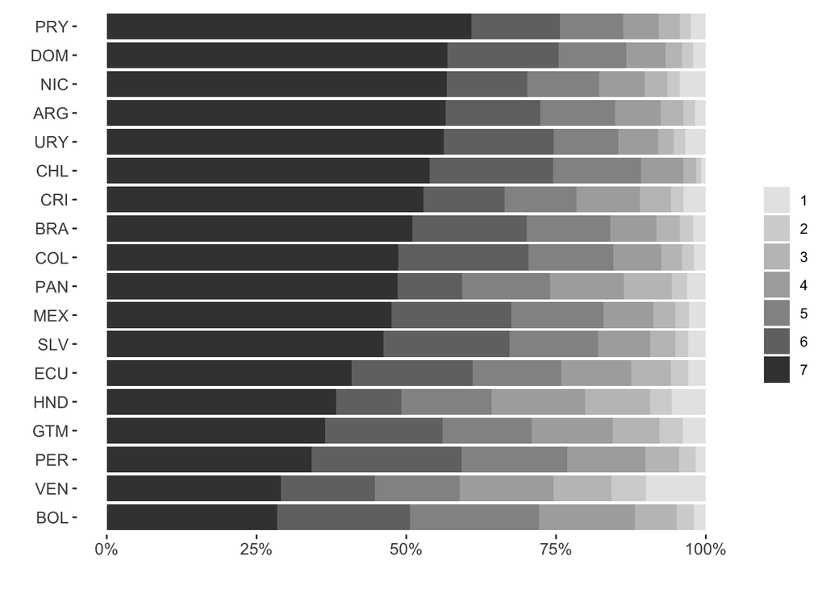

```r
#Database: Redistributive Preference by countries
redist <- xtabs(~country+redistribution, data=lapop1)
redist <- prop.table(redist, 1)*100
redist <- as.data.frame(redist)
redist <-redist[order(-redist$Freq, redist$redistribution),]
rownames(redist) <- 1:nrow(redist)
redist$countryname[redist$country=="BOL"] <- 1
redist$countryname[redist$country=="VEN"] <- 2
redist$countryname[redist$country=="PER"] <- 3
redist$countryname[redist$country=="GTM"] <- 4
redist$countryname[redist$country=="HND"] <- 5
redist$countryname[redist$country=="ECU"] <- 6
redist$countryname[redist$country=="SLV"] <- 7
redist$countryname[redist$country=="MEX"] <- 8
redist$countryname[redist$country=="PAN"] <- 9
redist$countryname[redist$country=="COL"] <- 10
redist$countryname[redist$country=="BRA"] <- 11
redist$countryname[redist$country=="CRI"] <- 12
redist$countryname[redist$country=="CHL"] <- 13
redist$countryname[redist$country=="URY"] <- 14
redist$countryname[redist$country=="ARG"] <- 15
redist$countryname[redist$country=="NIC"] <- 16
redist$countryname[redist$country=="DOM"] <- 17
redist$countryname[redist$country=="PRY"] <- 18
redist$countryname <- factor(redist$countryname,
levels = c(1:18),
labels = c("BOL","VEN","PER","GTM","HND","ECU","SLV","MEX","PAN","COL","BRA","CRI","CHL","URY","ARG","NIC","DOM","PRY"))
redist$order <- factor(redist$country,
levels = c("BOL","VEN","PER","GTM","HND","ECU","SLV","MEX","PAN","COL","BRA","CRI","CHL","URY","ARG","NIC","DOM","PRY"),
labels = c(1:18))

#Figure 2: Redistributive Preference by countries
figure2 = ggplot(data = redist, aes(x=reorder(countryname, order), y = Freq, fill = factor(redistribution))) + geom_bar(stat = "identity") + coord_flip() + labs(x = "", y = "", fill="") +
  scale_fill_grey(start = .9, end = .25, name=" ") +
  scale_y_continuous(labels = function(Freq){paste0(Freq, "%") }) +
  theme(panel.background = element_rect(fill = "white"),
        axis.text=element_text(size=10),
        strip.text=element_text(size=12))
figure2
```

```r
ggsave("Graphs/Figure2.png", plot=figure2)
```

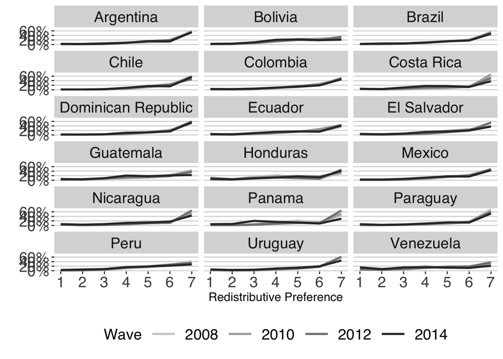

```r
lapop1=as.data.frame(lapop1) #Transformation to Data Frame
#Figure 3: Redistributive Preference by country and year
figure3 = ggplot(lapop1, aes(x= redistribution,  colour= year)) +
  geom_line(aes(y = ..prop.., fill = factor(..x..)), stat="count", binwidth = 1, size = 1) +
  facet_wrap(~countryname, ncol=3) +
  xlim(1, 7) +
  labs(x = "Redistributive Preference", y = "", fill="") +
  scale_color_grey(start=0.8, end=0.2, name="Wave") +
  scale_y_continuous(labels = scales::percent_format(accuracy = 1)) +
  scale_x_continuous(breaks = c(1:7)) +
  theme(axis.text=element_text(size=15),
        strip.text=element_text(size=15),
        legend.text=element_text(size=15),
        legend.title=element_text(size=15),
        legend.key.size=unit(1,"cm"),
        legend.position = "bottom",
        panel.background = element_rect(fill = "white")) +
  theme_hc()
figure3
```

```r
ggsave("Graphs/Figure3.png", plot=figure3, height = 10, width = 10, units="in")
```

- Average redistributive preference by quintil/decile of income by country

```r
#Table3: Average redistribution by quintil of income deciles, by country
redis_quintil = with(lapop1, tapply(redistribution, list(countryname, quintil_f), mean))
redis_quintil = as.data.frame(redis_quintil)
redis_quintil$total <- rowMeans(redis_quintil[c("1", "2", "3", "4", "5", "6")])
stargazer(redis_quintil)
```

```
##
## % Table created by stargazer v.5.2.2 by Marek Hlavac, Harvard University. E-mail: hlavac at fas.harvard.edu
## % Date and time: Fri, Feb 01, 2019 - 10:45:09
## \begin{table}[!htbp] \centering
##   \caption{}
##   \label{}
## \begin{tabular}{@{\extracolsep{5pt}}lccccccc}
## \\[-1.8ex]\hline
## \hline \\[-1.8ex]
## Statistic & \multicolumn{1}{c}{N} & \multicolumn{1}{c}{Mean} & \multicolumn{1}{c}{St. Dev.} & \multicolumn{1}{c}{Min} & \multicolumn{1}{c}{Pctl(25)} & \multicolumn{1}{c}{Pctl(75)} & \multicolumn{1}{c}{Max} \\
## \hline \\[-1.8ex]
## 1 & 18 & 5.732 & 0.359 & 4.888 & 5.578 & 6.037 & 6.147 \\
## 2 & 18 & 5.729 & 0.349 & 4.988 & 5.580 & 6.003 & 6.182 \\
## 3 & 18 & 5.713 & 0.360 & 4.737 & 5.543 & 5.948 & 6.103 \\
## 4 & 18 & 5.709 & 0.352 & 4.858 & 5.506 & 5.967 & 6.121 \\
## 5 & 18 & 5.650 & 0.376 & 4.625 & 5.497 & 5.909 & 6.110 \\
## 6 & 18 & 5.699 & 0.357 & 4.816 & 5.533 & 5.974 & 6.105 \\
## total & 18 & 5.705 & 0.355 & 4.818 & 5.548 & 5.974 & 6.117 \\
## \hline \\[-1.8ex]
## \end{tabular}
## \end{table}
```

```r
#Table3: Average redistribution preference of income deciles, by country
redis_decil = with(lapop1, tapply(redistribution, list(countryname, decil_f), mean))
redis_decil = as.data.frame(redis_decil)
redis_decil$total <- rowMeans(redis_decil[c("1", "2", "3", "4", "5", "6", "7", "8", "9", "10", "11")])
stargazer(redis_decil)
```

```
##
## % Table created by stargazer v.5.2.2 by Marek Hlavac, Harvard University. E-mail: hlavac at fas.harvard.edu
## % Date and time: Fri, Feb 01, 2019 - 10:45:09
## \begin{table}[!htbp] \centering
##   \caption{}
##   \label{}
## \begin{tabular}{@{\extracolsep{5pt}}lccccccc}
## \\[-1.8ex]\hline
## \hline \\[-1.8ex]
## Statistic & \multicolumn{1}{c}{N} & \multicolumn{1}{c}{Mean} & \multicolumn{1}{c}{St. Dev.} & \multicolumn{1}{c}{Min} & \multicolumn{1}{c}{Pctl(25)} & \multicolumn{1}{c}{Pctl(75)} & \multicolumn{1}{c}{Max} \\
## \hline \\[-1.8ex]
## 1 & 18 & 5.760 & 0.358 & 4.970 & 5.515 & 6.023 & 6.209 \\
## 2 & 18 & 5.704 & 0.367 & 4.803 & 5.604 & 5.998 & 6.106 \\
## 3 & 18 & 5.707 & 0.354 & 4.995 & 5.482 & 6.010 & 6.135 \\
## 4 & 18 & 5.751 & 0.349 & 4.980 & 5.562 & 5.997 & 6.229 \\
## 5 & 18 & 5.695 & 0.365 & 4.661 & 5.521 & 5.896 & 6.128 \\
## 6 & 18 & 5.731 & 0.365 & 4.813 & 5.561 & 6.014 & 6.198 \\
## 7 & 18 & 5.681 & 0.360 & 4.831 & 5.479 & 5.956 & 6.140 \\
## 8 & 18 & 5.738 & 0.347 & 4.885 & 5.532 & 6.005 & 6.102 \\
## 9 & 18 & 5.638 & 0.390 & 4.615 & 5.448 & 5.907 & 6.063 \\
## 10 & 18 & 5.661 & 0.368 & 4.635 & 5.532 & 5.899 & 6.158 \\
## 11 & 18 & 5.699 & 0.357 & 4.816 & 5.533 & 5.974 & 6.105 \\
## total & 18 & 5.706 & 0.355 & 4.819 & 5.549 & 5.974 & 6.118 \\
## \hline \\[-1.8ex]
## \end{tabular}
## \end{table}
```

- Average redistributive preference by wave and country

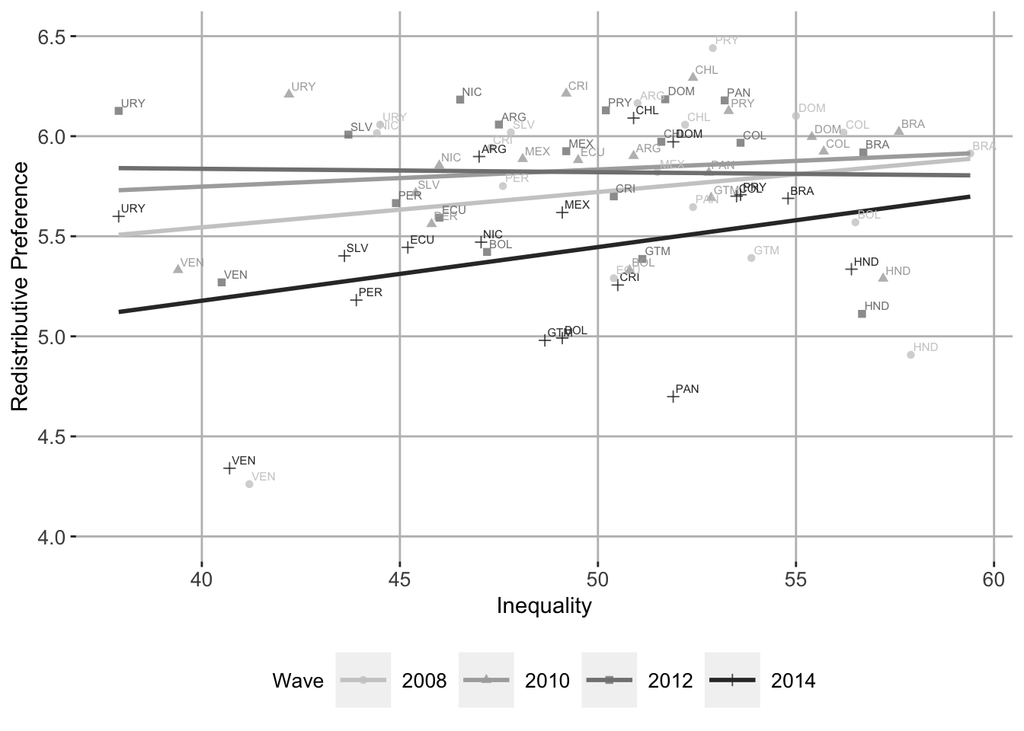

```r
#Figure 3a: Average redistribution - GINI
lapop$welfare1=as.factor(lapop$welfare)
lapop$welfare1=as.integer(lapop$welfare1)
lapop_country_year = aggregate(lapop,
                          by=list(lapop$country, lapop$countryname, lapop$wave,
                                  lapop$country_wave), FUN=mean, na.rm=TRUE)
lapop_country_year1 = select(lapop_country_year,Group.1, Group.2, Group.3, Group.4,
                      redistribution, gini, gdp, sysconf, gsocial, unemployment, informal, welfare1)
colnames(lapop_country_year1) <- c("country", "countryname", "wave", "country_wave", "redistribution", "gini", "gdp", "sysconf", "gsocial", "unemployment", "informal", "welfare")

#Figure 3a: Average redistribution - GINI
figure3a= ggplot(lapop_country_year1,
            aes(x= gini, y= redistribution, label=country, color=factor(wave+2000), shape=factor(wave+2000))) +
  geom_point(size = 1.5, alpha = 0.8) +
  stat_smooth(size = 1, method = "lm", se = FALSE, fullrange = TRUE) +   geom_text(aes(label=country),hjust=-0.1, vjust=-0.5, size=2, show.legend = FALSE) +
  labs(x = "Inequality", y =  "Redistributive Preference") +
  scale_color_grey(start=0.8, end=0.2, name="Wave") +
  scale_y_continuous( "Redistributive Preference", limits = c(4,6.5),
                     breaks = c(4, 4.5,5, 5.5, 6, 6.5)) +
  scale_x_continuous("Inequality",
                     breaks = c(40, 45, 50, 55, 60)) +
  theme(panel.grid.major = element_line(colour = "grey"),
        legend.position="bottom",
        axis.text=element_text(size=10),
        strip.text=element_text(size=10),
        legend.text=element_text(size=10),
        legend.title=element_text(size=10),
        legend.key.size=unit(1,"cm"),
        panel.background = element_rect(fill = "white"))
figure3a =figure3a + scale_color_grey(start=0.8, end=0.2) + labs(shape='Wave', color='Wave')
figure3a_color =figure3a + scale_color_brewer(palette="Dark2") + labs(shape='Wave', color='Wave')
figure3a
```

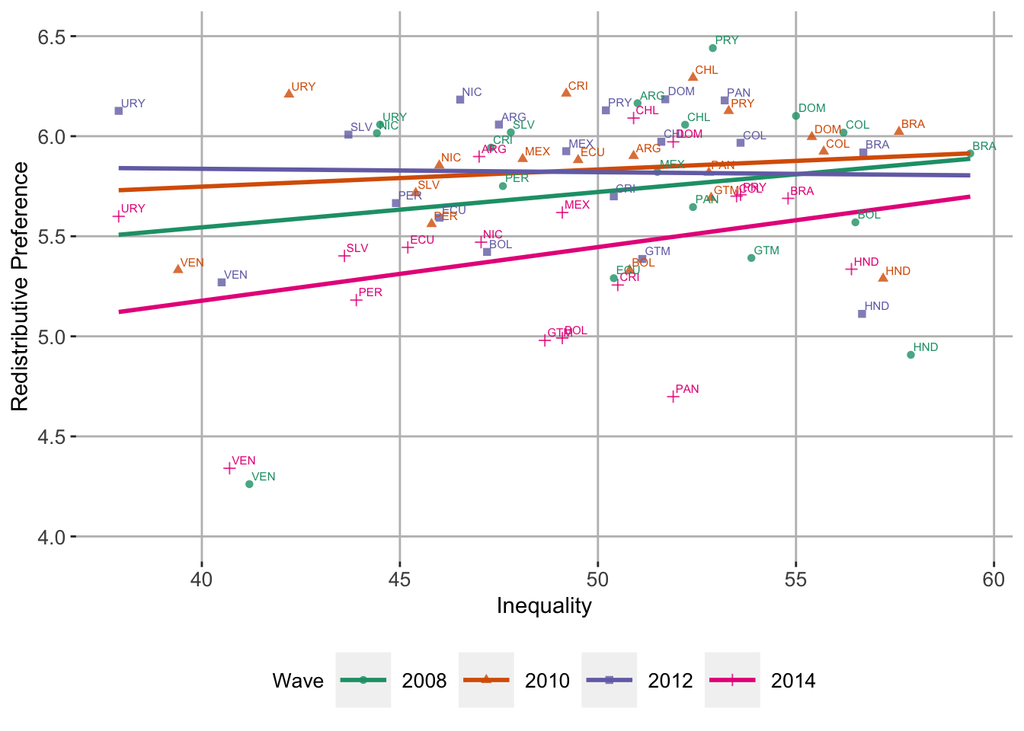

```r
figure3a_color
```

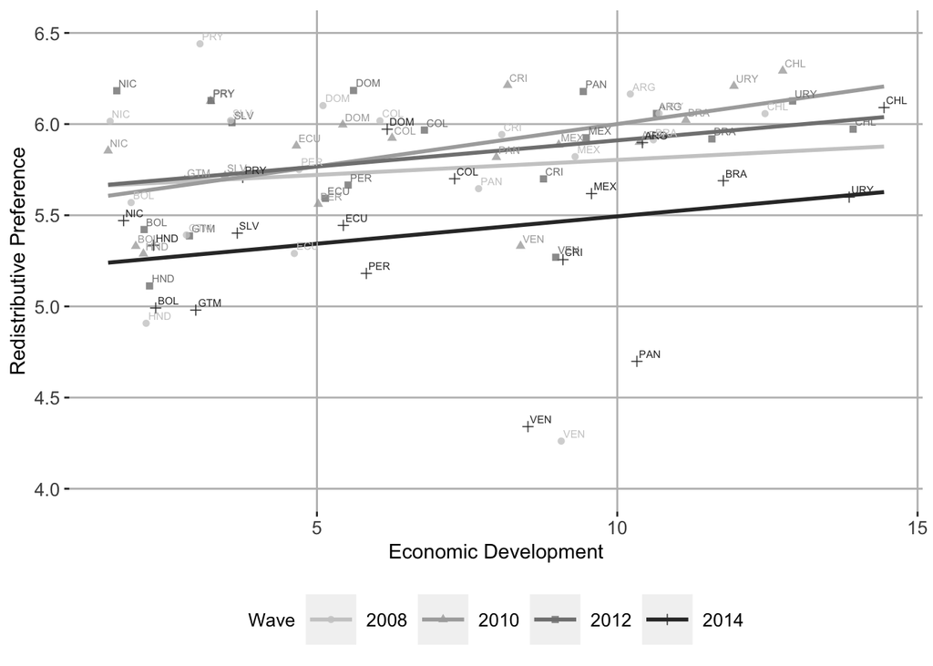

```r
ggsave("Graphs/Figure3a.png", plot=figure3a)
ggsave("Graphs/Figure3a_color.png", plot=figure3a_color)


#Figure 3b: Average redistribution - PIB
figure3b= ggplot(lapop_country_year1,
            aes(x= gdp, y= redistribution, label=country, color=factor(wave+2000), shape=factor(wave+2000))) +
  geom_point(size = 1.5, alpha = 0.8) +
  stat_smooth(size = 1, method = "lm", se = FALSE, fullrange = TRUE) +   geom_text(aes(label=country),hjust=-0.1, vjust=-0.5, size=2, show.legend = FALSE) +
  labs(x = "", y =  "Redistributive Preference") +
  scale_color_grey(start=0.8, end=0.2, name="Wave") +
  scale_y_continuous( "Redistributive Preference", limits = c(4,6.5),
                     breaks = c(4, 4.5,5, 5.5, 6, 6.5)) +
  scale_x_continuous("Economic Development",
                     breaks = c(0,5,10,15,20)) +
  theme(panel.grid.major = element_line(colour = "grey"),
        legend.position="bottom",
        axis.text=element_text(size=10),
        strip.text=element_text(size=10),
        legend.text=element_text(size=10),
        legend.title=element_text(size=10),
        legend.key.size=unit(1,"cm"),
        panel.background = element_rect(fill = "white"))
figure3b =figure3b + scale_color_grey(start=0.8, end=0.2) + labs(shape='Wave', color='Wave')
figure3b_color =figure3b + scale_color_brewer(palette="Dark2") + labs(shape='Wave', color='Wave')
figure3b
```

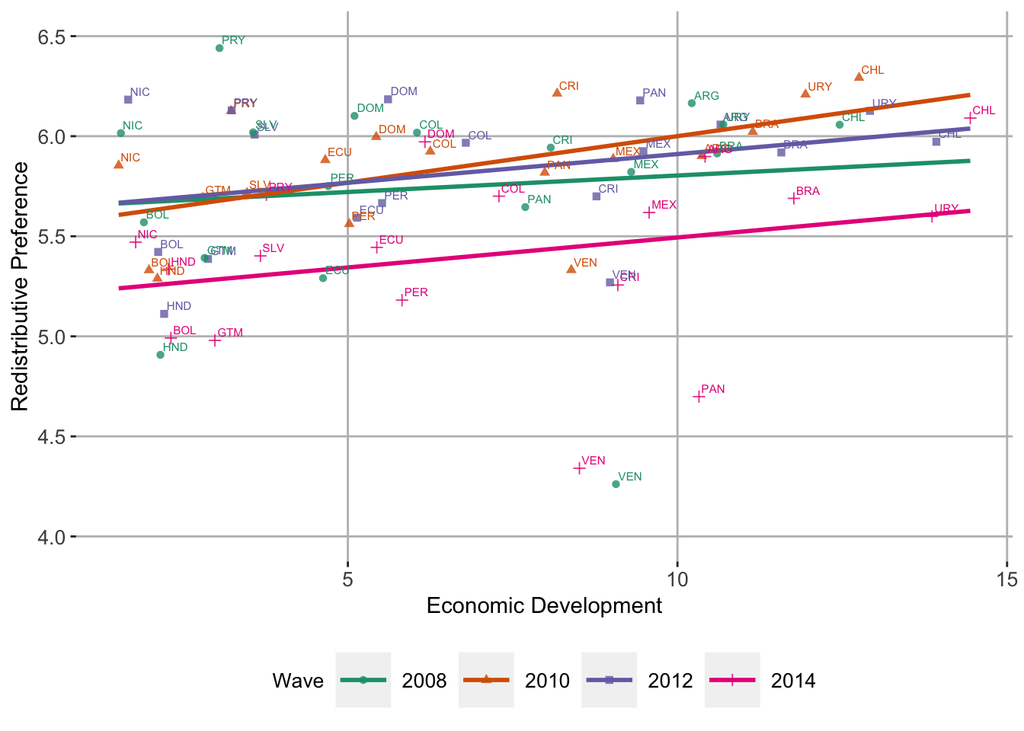

```r
figure3b_color
```

```r
ggsave("Graphs/Figure3b.png", plot=figure3b)
ggsave("Graphs/Figure3b_color.png", plot=figure3b_color)
```

- Multilevel estimation: Weighted models

```r
#Null model: Country Year
model_w0 = lmer(redistribution ~ 1 + (1 | country_wave) + (1 | countryname), data=lapop1, weights=wt)
screenreg(model_w0,  stars = c(0.01,0.05,0.1))
```

```
##
## =============================================
##                                Model 1
## ---------------------------------------------
## (Intercept)                          5.70 ***
##                                     (0.08)
## ---------------------------------------------
## AIC                             429583.50
## BIC                             429622.07
## Log Likelihood                 -214787.75
## Num. obs.                       113804
## Num. groups: country_wave           72
## Num. groups: countryname            18
## Var: country_wave (Intercept)        0.09
## Var: countryname (Intercept)         0.11
## Var: Residual                        2.40
## =============================================
## *** p < 0.01, ** p < 0.05, * p < 0.1
```

```r
#Intraclass correlation estimation (ICC)
varcomp=as.data.frame(VarCorr(model_w0))
varcomp
```

```
##            grp        var1 var2       vcov     sdcor
## 1 country_wave (Intercept) <NA> 0.08944892 0.2990801
## 2  countryname (Intercept) <NA> 0.10659423 0.3264877
## 3     Residual        <NA> <NA> 2.40378531 1.5504146
```

```r
o2country=varcomp[2,4]
o2country_year=varcomp[1,4]
o2individual=varcomp[3,4]
icc_country=o2country/(o2country+o2country_year+o2individual)
icc_country_year=o2country_year/(o2country+o2country_year+o2individual)
icc_individual=o2individual/(o2country+o2country_year+o2individual)

icc_country #0.04100065
```

```
## [1] 0.04100049
```

```r
icc_country_year #0.03440478
```

```
## [1] 0.0344057
```

```r
icc_individual #0.9245946
```

```
## [1] 0.9245938
```

```r
#1.Model: redistribution
model_w1 = lmer(redistribution ~ 1 + decil_d
                + year + (1 | country_wave)
                + (1 | countryname), data=lapop1, weights=wt)
screenreg(model_w1,  stars = c(0.01,0.05,0.1))
```

```
##
## =============================================
##                                Model 1
## ---------------------------------------------
## (Intercept)                          5.76 ***
##                                     (0.10)
## decil_dDecil 9-10                   -0.05 ***
##                                     (0.01)
## year2010                             0.09
##                                     (0.08)
## year2012                             0.07
##                                     (0.08)
## year2014                            -0.34 ***
##                                     (0.08)
## ---------------------------------------------
## AIC                             429561.56
## BIC                             429638.70
## Log Likelihood                 -214772.78
## Num. obs.                       113804
## Num. groups: country_wave           72
## Num. groups: countryname            18
## Var: country_wave (Intercept)        0.05
## Var: countryname (Intercept)         0.12
## Var: Residual                        2.40
## =============================================
## *** p < 0.01, ** p < 0.05, * p < 0.1
```

```r
##2.Model: individual predictors (H4)
model_w2 = lmer(redistribution ~ 1 + decil_d + man + age + married_f
                + ideology_f + sysconf + employment_r + education_r
                + zone + year + (1 | country_wave) + (1 | countryname), data=lapop1, weights=wt)
screenreg(model_w2,  stars = c(0.01,0.05,0.1))
```

```
##
## =============================================
##                                Model 1
## ---------------------------------------------
## (Intercept)                          5.38 ***
##                                     (0.10)
## decil_dDecil 9-10                   -0.04 ***
##                                     (0.01)
## manMan                               0.03 ***
##                                     (0.01)
## age                                  0.00
##                                     (0.00)
## married_fMarried                     0.02 **
##                                     (0.01)
## ideology_fCenter                    -0.00
##                                     (0.01)
## ideology_fLeft                       0.10 ***
##                                     (0.01)
## ideology_fNot declared               0.16 ***
##                                     (0.01)
## sysconf                              0.08 ***
##                                     (0.00)
## employment_rUnemployed               0.05 ***
##                                     (0.02)
## employment_rEmployee                 0.04 **
##                                     (0.01)
## education_rSecondary                 0.03 ***
##                                     (0.01)
## education_rTertiary                  0.01
##                                     (0.01)
## zoneUrban                           -0.06 ***
##                                     (0.01)
## year2010                             0.07
##                                     (0.08)
## year2012                             0.05
##                                     (0.08)
## year2014                            -0.34 ***
##                                     (0.08)
## ---------------------------------------------
## AIC                             428979.26
## BIC                             429172.11
## Log Likelihood                 -214469.63
## Num. obs.                       113804
## Num. groups: country_wave           72
## Num. groups: countryname            18
## Var: country_wave (Intercept)        0.05
## Var: countryname (Intercept)         0.11
## Var: Residual                        2.39
## =============================================
## *** p < 0.01, ** p < 0.05, * p < 0.1
```

```r
###3. Model: individual predictors + GINI (H1 Y H2)
model_w3 = lmer(redistribution ~ 1 + decil_d + man + age + married_f
                + ideology_f + sysconf + employment_r + education_r
                + zone + gini_mean + gini_dif + year
                + (1 | country_wave) + (1 | countryname), data=lapop1, weights=wt)
screenreg(model_w3,  stars = c(0.01,0.05,0.1))
```

```
##
## =============================================
##                                Model 1
## ---------------------------------------------
## (Intercept)                          4.71 ***
##                                     (0.90)
## decil_dDecil 9-10                   -0.04 ***
##                                     (0.01)
## manMan                               0.03 ***
##                                     (0.01)
## age                                  0.00
##                                     (0.00)
## married_fMarried                     0.02 **
##                                     (0.01)
## ideology_fCenter                    -0.00
##                                     (0.01)
## ideology_fLeft                       0.10 ***
##                                     (0.01)
## ideology_fNot declared               0.16 ***
##                                     (0.01)
## sysconf                              0.08 ***
##                                     (0.00)
## employment_rUnemployed               0.05 ***
##                                     (0.02)
## employment_rEmployee                 0.04 **
##                                     (0.01)
## education_rSecondary                 0.03 ***
##                                     (0.01)
## education_rTertiary                  0.01
##                                     (0.01)
## zoneUrban                           -0.06 ***
##                                     (0.01)
## gini_mean                            0.01
##                                     (0.02)
## gini_dif                            -0.00
##                                     (0.02)
## year2010                             0.07
##                                     (0.08)
## year2012                             0.05
##                                     (0.09)
## year2014                            -0.35 ***
##                                     (0.10)
## ---------------------------------------------
## AIC                             428994.77
## BIC                             429206.90
## Log Likelihood                 -214475.39
## Num. obs.                       113804
## Num. groups: country_wave           72
## Num. groups: countryname            18
## Var: country_wave (Intercept)        0.05
## Var: countryname (Intercept)         0.11
## Var: Residual                        2.39
## =============================================
## *** p < 0.01, ** p < 0.05, * p < 0.1
```

```r
####4 Model: individual predictors + GINI  + GDP
model_w4 = lmer(redistribution ~ 1 + decil_d + man + age + married_f
                + ideology_f + sysconf + employment_r + education_r
                + zone + gini_mean + gini_dif
                + gdp_mean + gdp_dif + year
                + (1 | country_wave) + (1 | countryname), data=lapop1, weights=wt)
screenreg(model_w4,  stars = c(0.01,0.05,0.1))
```

```
##
## =============================================
##                                Model 1
## ---------------------------------------------
## (Intercept)                          4.27 ***
##                                     (0.90)
## decil_dDecil 9-10                   -0.04 ***
##                                     (0.01)
## manMan                               0.03 ***
##                                     (0.01)
## age                                  0.00
##                                     (0.00)
## married_fMarried                     0.02 **
##                                     (0.01)
## ideology_fCenter                    -0.00
##                                     (0.01)
## ideology_fLeft                       0.10 ***
##                                     (0.01)
## ideology_fNot declared               0.16 ***
##                                     (0.01)
## sysconf                              0.08 ***
##                                     (0.00)
## employment_rUnemployed               0.05 ***
##                                     (0.02)
## employment_rEmployee                 0.04 **
##                                     (0.01)
## education_rSecondary                 0.03 ***
##                                     (0.01)
## education_rTertiary                  0.01
##                                     (0.01)
## zoneUrban                           -0.07 ***
##                                     (0.01)
## gini_mean                            0.02
##                                     (0.02)
## gini_dif                            -0.00
##                                     (0.02)
## gdp_mean                             0.04
##                                     (0.02)
## gdp_dif                             -0.11
##                                     (0.08)
## year2010                             0.08
##                                     (0.08)
## year2012                             0.11
##                                     (0.10)
## year2014                            -0.25 **
##                                     (0.12)
## ---------------------------------------------
## AIC                             429003.31
## BIC                             429234.72
## Log Likelihood                 -214477.65
## Num. obs.                       113804
## Num. groups: country_wave           72
## Num. groups: countryname            18
## Var: country_wave (Intercept)        0.05
## Var: countryname (Intercept)         0.10
## Var: Residual                        2.39
## =============================================
## *** p < 0.01, ** p < 0.05, * p < 0.1
```

```r
#####5. Model: individual predictors + GINI  + GDP + Welfare State (H3)
model_w5 = lmer(redistribution ~ 1 + decil_d + man + age + married_f
                + ideology_f + sysconf + employment_r + education_r
                + zone + gini_mean + gini_dif
                + gdp_mean + gdp_dif
                + welfare + year
                + (1 | country_wave) + (1 | countryname), data=lapop1, weights=wt)
screenreg(model_w5,  stars = c(0.01,0.05,0.1))
```

```
##
## =============================================
##                                Model 1
## ---------------------------------------------
## (Intercept)                          4.68 ***
##                                     (1.01)
## decil_dDecil 9-10                   -0.04 ***
##                                     (0.01)
## manMan                               0.03 ***
##                                     (0.01)
## age                                  0.00
##                                     (0.00)
## married_fMarried                     0.02 **
##                                     (0.01)
## ideology_fCenter                    -0.00
##                                     (0.01)
## ideology_fLeft                       0.10 ***
##                                     (0.01)
## ideology_fNot declared               0.16 ***
##                                     (0.01)
## sysconf                              0.08 ***
##                                     (0.00)
## employment_rUnemployed               0.05 ***
##                                     (0.02)
## employment_rEmployee                 0.04 **
##                                     (0.01)
## education_rSecondary                 0.03 ***
##                                     (0.01)
## education_rTertiary                  0.01
##                                     (0.01)
## zoneUrban                           -0.07 ***
##                                     (0.01)
## gini_mean                            0.01
##                                     (0.02)
## gini_dif                            -0.00
##                                     (0.02)
## gdp_mean                            -0.00
##                                     (0.05)
## gdp_dif                             -0.11
##                                     (0.08)
## welfareProductivista                 0.49
##                                     (0.45)
## welfareProteccionista                0.23
##                                     (0.33)
## year2010                             0.08
##                                     (0.08)
## year2012                             0.11
##                                     (0.10)
## year2014                            -0.25 **
##                                     (0.12)
## ---------------------------------------------
## AIC                             429007.03
## BIC                             429257.73
## Log Likelihood                 -214477.52
## Num. obs.                       113804
## Num. groups: country_wave           72
## Num. groups: countryname            18
## Var: country_wave (Intercept)        0.05
## Var: countryname (Intercept)         0.11
## Var: Residual                        2.39
## =============================================
## *** p < 0.01, ** p < 0.05, * p < 0.1
```

```r
######6. Model: country, country_year  Model: individual predictors + GINI + GDP (Decil Aleatorio) (H4.2)
model_w6 = lmer(redistribution ~ 1 + decil_d + man + age + married_f
                + ideology_f + sysconf + employment_r + education_r
                + zone + gini_mean + gini_dif
                + gdp_mean + gdp_dif + year
                + (1 + decil_d| country_wave) + (1 + decil_d | countryname), data=lapop1, weights=wt)
screenreg(model_w6, stars = c(0.01,0.05,0.1))
```

```
##
## ===============================================================
##                                                  Model 1
## ---------------------------------------------------------------
## (Intercept)                                            4.38 ***
##                                                       (0.87)
## decil_dDecil 9-10                                     -0.04 **
##                                                       (0.02)
## manMan                                                 0.03 ***
##                                                       (0.01)
## age                                                    0.00
##                                                       (0.00)
## married_fMarried                                       0.02 **
##                                                       (0.01)
## ideology_fCenter                                      -0.00
##                                                       (0.01)
## ideology_fLeft                                         0.10 ***
##                                                       (0.01)
## ideology_fNot declared                                 0.16 ***
##                                                       (0.01)
## sysconf                                                0.08 ***
##                                                       (0.00)
## employment_rUnemployed                                 0.05 ***
##                                                       (0.02)
## employment_rEmployee                                   0.04 **
##                                                       (0.01)
## education_rSecondary                                   0.03 ***
##                                                       (0.01)
## education_rTertiary                                    0.01
##                                                       (0.01)
## zoneUrban                                             -0.07 ***
##                                                       (0.01)
## gini_mean                                              0.01
##                                                       (0.02)
## gini_dif                                              -0.00
##                                                       (0.02)
## gdp_mean                                               0.04 *
##                                                       (0.02)
## gdp_dif                                               -0.11
##                                                       (0.08)
## year2010                                               0.09
##                                                       (0.08)
## year2012                                               0.11
##                                                       (0.10)
## year2014                                              -0.25 **
##                                                       (0.12)
## ---------------------------------------------------------------
## AIC                                               429005.25
## BIC                                               429275.23
## Log Likelihood                                   -214474.63
## Num. obs.                                         113804
## Num. groups: country_wave                             72
## Num. groups: countryname                              18
## Var: country_wave (Intercept)                          0.05
## Var: country_wave decil_dDecil 9-10                    0.00
## Cov: country_wave (Intercept) decil_dDecil 9-10       -0.00
## Var: countryname (Intercept)                           0.10
## Var: countryname decil_dDecil 9-10                     0.00
## Cov: countryname (Intercept) decil_dDecil 9-10         0.01
## Var: Residual                                          2.39
## ===============================================================
## *** p < 0.01, ** p < 0.05, * p < 0.1
```

```r
#######7. Model: country, country_year  Model: individual predictors + GINI + GDP (Decil Aleatorio) (Decil*GINI) (H5)
model_w7 = lmer(redistribution ~ 1 + decil_d + man + age + married_f
                + ideology_f + sysconf + employment_r + education_r
                + zone + gini_mean + gini_dif
                + gdp_mean + gdp_dif
                + decil_d*gini_mean + decil_d*gini_dif + year
                + (1 + decil_d | country_wave) + (1 + decil_d | countryname), data=lapop1, weights=wt)
screenreg(model_w7,  stars = c(0.01,0.05,0.1))
```

```
##
## ===============================================================
##                                                  Model 1
## ---------------------------------------------------------------
## (Intercept)                                            4.24 ***
##                                                       (0.89)
## decil_dDecil 9-10                                     -0.19
##                                                       (0.19)
## manMan                                                 0.03 ***
##                                                       (0.01)
## age                                                    0.00
##                                                       (0.00)
## married_fMarried                                       0.02 **
##                                                       (0.01)
## ideology_fCenter                                      -0.00
##                                                       (0.01)
## ideology_fLeft                                         0.10 ***
##                                                       (0.01)
## ideology_fNot declared                                 0.16 ***
##                                                       (0.01)
## sysconf                                                0.08 ***
##                                                       (0.00)
## employment_rUnemployed                                 0.05 ***
##                                                       (0.02)
## employment_rEmployee                                   0.04 **
##                                                       (0.01)
## education_rSecondary                                   0.03 ***
##                                                       (0.01)
## education_rTertiary                                    0.01
##                                                       (0.01)
## zoneUrban                                             -0.07 ***
##                                                       (0.01)
## gini_mean                                              0.02
##                                                       (0.02)
## gini_dif                                              -0.01
##                                                       (0.02)
## gdp_mean                                               0.04 *
##                                                       (0.02)
## gdp_dif                                               -0.11
##                                                       (0.08)
```

[output cut: 11 more lines]

```
## AIC                                               429022.42
## BIC                                               429311.69
## Log Likelihood                                   -214481.21
## Num. obs.                                         113804
## Num. groups: country_wave                             72
## Num. groups: countryname                              18
## Var: country_wave (Intercept)                          0.05
## Var: country_wave decil_dDecil 9-10                    0.00
## Cov: country_wave (Intercept) decil_dDecil 9-10       -0.00
## Var: countryname (Intercept)                           0.10
## Var: countryname decil_dDecil 9-10                     0.00
## Cov: countryname (Intercept) decil_dDecil 9-10         0.01
## Var: Residual                                          2.39
## ===============================================================
## *** p < 0.01, ** p < 0.05, * p < 0.1
```

```r
########8. Model: country, country_year  Model: individual predictors + GINI + GDP (Decil Aleatorio) (Decil*GDP)
model_w8 = lmer(redistribution ~ 1 + decil_d + man + age + married_f
                + ideology_f + sysconf + employment_r + education_r
                + zone + gini_mean + gini_dif
                + gdp_mean + gdp_dif
                + decil_d*gdp_mean + decil_d*gdp_dif + year
                + (1 + decil_d | country_wave) + (1 + decil_d | countryname), data=lapop1, weights=wt)
screenreg(model_w8,  stars = c(0.01,0.05,0.1))
```

```
##
## ===============================================================
##                                                  Model 1
## ---------------------------------------------------------------
## (Intercept)                                            4.42 ***
##                                                       (0.86)
## decil_dDecil 9-10                                     -0.01
##                                                       (0.04)
## manMan                                                 0.03 ***
##                                                       (0.01)
## age                                                    0.00
##                                                       (0.00)
## married_fMarried                                       0.02 **
##                                                       (0.01)
## ideology_fCenter                                      -0.00
##                                                       (0.01)
## ideology_fLeft                                         0.10 ***
##                                                       (0.01)
## ideology_fNot declared                                 0.16 ***
##                                                       (0.01)
## sysconf                                                0.08 ***
##                                                       (0.00)
## employment_rUnemployed                                 0.05 ***
##                                                       (0.02)
## employment_rEmployee                                   0.04 **
##                                                       (0.01)
## education_rSecondary                                   0.03 ***
##                                                       (0.01)
## education_rTertiary                                    0.01
##                                                       (0.01)
## zoneUrban                                             -0.07 ***
##                                                       (0.01)
## gini_mean                                              0.01
##                                                       (0.02)
## gini_dif                                              -0.00
##                                                       (0.02)
## gdp_mean                                               0.04
##                                                       (0.02)
## gdp_dif                                               -0.11
##                                                       (0.08)
```

[output cut: 11 more lines]

```
## AIC                                               429022.17
## BIC                                               429311.43
## Log Likelihood                                   -214481.08
## Num. obs.                                         113804
## Num. groups: country_wave                             72
## Num. groups: countryname                              18
## Var: country_wave (Intercept)                          0.05
## Var: country_wave decil_dDecil 9-10                    0.00
## Cov: country_wave (Intercept) decil_dDecil 9-10       -0.00
## Var: countryname (Intercept)                           0.10
## Var: countryname decil_dDecil 9-10                     0.00
## Cov: countryname (Intercept) decil_dDecil 9-10         0.01
## Var: Residual                                          2.39
## ===============================================================
## *** p < 0.01, ** p < 0.05, * p < 0.1
```

```r
#All Weighted models
texreg(list(model_w0, model_w1, model_w2, model_w3, model_w4,
            model_w5, model_w6, model_w7, model_w8),
       stars = c(0.01,0.05,0.1), dcolumn = TRUE)
```

```
##
## \usepackage{dcolumn}
##
## \begin{table}
## \begin{center}
## \begin{tabular}{l D{.}{.}{7.5} D{.}{.}{7.5} D{.}{.}{7.5} D{.}{.}{7.5} D{.}{.}{7.5} D{.}{.}{7.5} D{.}{.}{7.5} D{.}{.}{7.5} D{.}{.}{7.5} }
## \hline
##  & \multicolumn{1}{c}{Model 1} & \multicolumn{1}{c}{Model 2} & \multicolumn{1}{c}{Model 3} & \multicolumn{1}{c}{Model 4} & \multicolumn{1}{c}{Model 5} & \multicolumn{1}{c}{Model 6} & \multicolumn{1}{c}{Model 7} & \multicolumn{1}{c}{Model 8} & \multicolumn{1}{c}{Model 9} \\
## \hline
## (Intercept)                                     & 5.70^{***} & 5.76^{***}  & 5.38^{***}  & 4.71^{***}  & 4.27^{***}  & 4.68^{***}  & 4.38^{***}  & 4.24^{***}  & 4.42^{***}  \\
##                                                 & (0.08)     & (0.10)      & (0.10)      & (0.90)      & (0.90)      & (1.01)      & (0.87)      & (0.89)      & (0.86)      \\
## decil\_dDecil 9-10                              &            & -0.05^{***} & -0.04^{***} & -0.04^{***} & -0.04^{***} & -0.04^{***} & -0.04^{**}  & -0.19       & -0.01       \\
##                                                 &            & (0.01)      & (0.01)      & (0.01)      & (0.01)      & (0.01)      & (0.02)      & (0.19)      & (0.04)      \\
## year2010                                        &            & 0.09        & 0.07        & 0.07        & 0.08        & 0.08        & 0.09        & 0.09        & 0.09        \\
##                                                 &            & (0.08)      & (0.08)      & (0.08)      & (0.08)      & (0.08)      & (0.08)      & (0.08)      & (0.08)      \\
## year2012                                        &            & 0.07        & 0.05        & 0.05        & 0.11        & 0.11        & 0.11        & 0.11        & 0.11        \\
##                                                 &            & (0.08)      & (0.08)      & (0.09)      & (0.10)      & (0.10)      & (0.10)      & (0.10)      & (0.10)      \\
## year2014                                        &            & -0.34^{***} & -0.34^{***} & -0.35^{***} & -0.25^{**}  & -0.25^{**}  & -0.25^{**}  & -0.25^{**}  & -0.25^{**}  \\
##                                                 &            & (0.08)      & (0.08)      & (0.10)      & (0.12)      & (0.12)      & (0.12)      & (0.12)      & (0.12)      \\
## manMan                                          &            &             & 0.03^{***}  & 0.03^{***}  & 0.03^{***}  & 0.03^{***}  & 0.03^{***}  & 0.03^{***}  & 0.03^{***}  \\
##                                                 &            &             & (0.01)      & (0.01)      & (0.01)      & (0.01)      & (0.01)      & (0.01)      & (0.01)      \\
## age                                             &            &             & 0.00        & 0.00        & 0.00        & 0.00        & 0.00        & 0.00        & 0.00        \\
##                                                 &            &             & (0.00)      & (0.00)      & (0.00)      & (0.00)      & (0.00)      & (0.00)      & (0.00)      \\
## married\_fMarried                               &            &             & 0.02^{**}   & 0.02^{**}   & 0.02^{**}   & 0.02^{**}   & 0.02^{**}   & 0.02^{**}   & 0.02^{**}   \\
##                                                 &            &             & (0.01)      & (0.01)      & (0.01)      & (0.01)      & (0.01)      & (0.01)      & (0.01)      \\
## ideology\_fCenter                               &            &             & -0.00       & -0.00       & -0.00       & -0.00       & -0.00       & -0.00       & -0.00       \\
```

[output cut: 58 more lines]

- Multilevel estimation: aditional analisys

```r
#LR Test: Test Modelos Anidados (Considera modelos con ponderadores)
lrtest (model_w0, model_w1)
```

```
## Likelihood ratio test
##
## Model 1: redistribution ~ 1 + (1 | country_wave) + (1 | countryname)
## Model 2: redistribution ~ 1 + decil_d + year + (1 | country_wave) + (1 |
##     countryname)
##   #Df  LogLik Df  Chisq Pr(>Chisq)
## 1   4 -214788
## 2   8 -214773  4 29.942   5.03e-06 ***
## ---
## Signif. codes:  0 '***' 0.001 '**' 0.01 '*' 0.05 '.' 0.1 ' ' 1
```

```r
lrtest (model_w1, model_w2)
```

```
## Likelihood ratio test
##
## Model 1: redistribution ~ 1 + decil_d + year + (1 | country_wave) + (1 |
##     countryname)
## Model 2: redistribution ~ 1 + decil_d + man + age + married_f + ideology_f +
##     sysconf + employment_r + education_r + zone + year + (1 |
##     country_wave) + (1 | countryname)
##   #Df  LogLik Df Chisq Pr(>Chisq)
## 1   8 -214773
## 2  20 -214470 12 606.3  < 2.2e-16 ***
## ---
## Signif. codes:  0 '***' 0.001 '**' 0.01 '*' 0.05 '.' 0.1 ' ' 1
```

```r
lrtest (model_w2, model_w3)
```

```
## Likelihood ratio test
##
## Model 1: redistribution ~ 1 + decil_d + man + age + married_f + ideology_f +
##     sysconf + employment_r + education_r + zone + year + (1 |
##     country_wave) + (1 | countryname)
## Model 2: redistribution ~ 1 + decil_d + man + age + married_f + ideology_f +
##     sysconf + employment_r + education_r + zone + gini_mean +
##     gini_dif + year + (1 | country_wave) + (1 | countryname)
##   #Df  LogLik Df  Chisq Pr(>Chisq)
## 1  20 -214470
## 2  22 -214475  2 11.511   0.003166 **
## ---
## Signif. codes:  0 '***' 0.001 '**' 0.01 '*' 0.05 '.' 0.1 ' ' 1
```

```r
lrtest (model_w3, model_w4)
```

```
## Likelihood ratio test
##
## Model 1: redistribution ~ 1 + decil_d + man + age + married_f + ideology_f +
##     sysconf + employment_r + education_r + zone + gini_mean +
##     gini_dif + year + (1 | country_wave) + (1 | countryname)
## Model 2: redistribution ~ 1 + decil_d + man + age + married_f + ideology_f +
##     sysconf + employment_r + education_r + zone + gini_mean +
##     gini_dif + gdp_mean + gdp_dif + year + (1 | country_wave) +
##     (1 | countryname)
##   #Df  LogLik Df Chisq Pr(>Chisq)
## 1  22 -214475
## 2  24 -214478  2 4.535     0.1036
```

```r
lrtest (model_w4, model_w5)
```

```
## Likelihood ratio test
##
## Model 1: redistribution ~ 1 + decil_d + man + age + married_f + ideology_f +
##     sysconf + employment_r + education_r + zone + gini_mean +
##     gini_dif + gdp_mean + gdp_dif + year + (1 | country_wave) +
##     (1 | countryname)
## Model 2: redistribution ~ 1 + decil_d + man + age + married_f + ideology_f +
##     sysconf + employment_r + education_r + zone + gini_mean +
##     gini_dif + gdp_mean + gdp_dif + welfare + year + (1 | country_wave) +
##     (1 | countryname)
##   #Df  LogLik Df  Chisq Pr(>Chisq)
## 1  24 -214478
## 2  26 -214478  2 0.2738     0.8721
```

```r
lrtest (model_w5, model_w6)
```

```
## Likelihood ratio test
##
## Model 1: redistribution ~ 1 + decil_d + man + age + married_f + ideology_f +
##     sysconf + employment_r + education_r + zone + gini_mean +
##     gini_dif + gdp_mean + gdp_dif + welfare + year + (1 | country_wave) +
##     (1 | countryname)
## Model 2: redistribution ~ 1 + decil_d + man + age + married_f + ideology_f +
##     sysconf + employment_r + education_r + zone + gini_mean +
##     gini_dif + gdp_mean + gdp_dif + year + (1 + decil_d | country_wave) +
##     (1 + decil_d | countryname)
##   #Df  LogLik Df  Chisq Pr(>Chisq)
## 1  26 -214478
## 2  28 -214475  2 5.7844    0.05546 .
## ---
## Signif. codes:  0 '***' 0.001 '**' 0.01 '*' 0.05 '.' 0.1 ' ' 1
```

```r
lrtest (model_w6, model_w7)
```

```
## Likelihood ratio test
##
## Model 1: redistribution ~ 1 + decil_d + man + age + married_f + ideology_f +
##     sysconf + employment_r + education_r + zone + gini_mean +
##     gini_dif + gdp_mean + gdp_dif + year + (1 + decil_d | country_wave) +
##     (1 + decil_d | countryname)
## Model 2: redistribution ~ 1 + decil_d + man + age + married_f + ideology_f +
##     sysconf + employment_r + education_r + zone + gini_mean +
##     gini_dif + gdp_mean + gdp_dif + decil_d * gini_mean + decil_d *
##     gini_dif + year + (1 + decil_d | country_wave) + (1 + decil_d |
##     countryname)
##   #Df  LogLik Df  Chisq Pr(>Chisq)
## 1  28 -214475
## 2  30 -214481  2 13.172   0.001379 **
## ---
## Signif. codes:  0 '***' 0.001 '**' 0.01 '*' 0.05 '.' 0.1 ' ' 1
```

```r
lrtest (model_w7, model_w8)
```

```
## Likelihood ratio test
##
## Model 1: redistribution ~ 1 + decil_d + man + age + married_f + ideology_f +
##     sysconf + employment_r + education_r + zone + gini_mean +
##     gini_dif + gdp_mean + gdp_dif + decil_d * gini_mean + decil_d *
##     gini_dif + year + (1 + decil_d | country_wave) + (1 + decil_d |
##     countryname)
## Model 2: redistribution ~ 1 + decil_d + man + age + married_f + ideology_f +
##     sysconf + employment_r + education_r + zone + gini_mean +
##     gini_dif + gdp_mean + gdp_dif + decil_d * gdp_mean + decil_d *
##     gdp_dif + year + (1 + decil_d | country_wave) + (1 + decil_d |
##     countryname)
##   #Df  LogLik Df  Chisq Pr(>Chisq)
## 1  30 -214481
## 2  30 -214481  0 0.2557  < 2.2e-16 ***
## ---
## Signif. codes:  0 '***' 0.001 '**' 0.01 '*' 0.05 '.' 0.1 ' ' 1
```

- Multilevel estimation: Figura 4. Random effect of income decile on agreement with redistribution by country (Model includes weight)

[figure not shown]

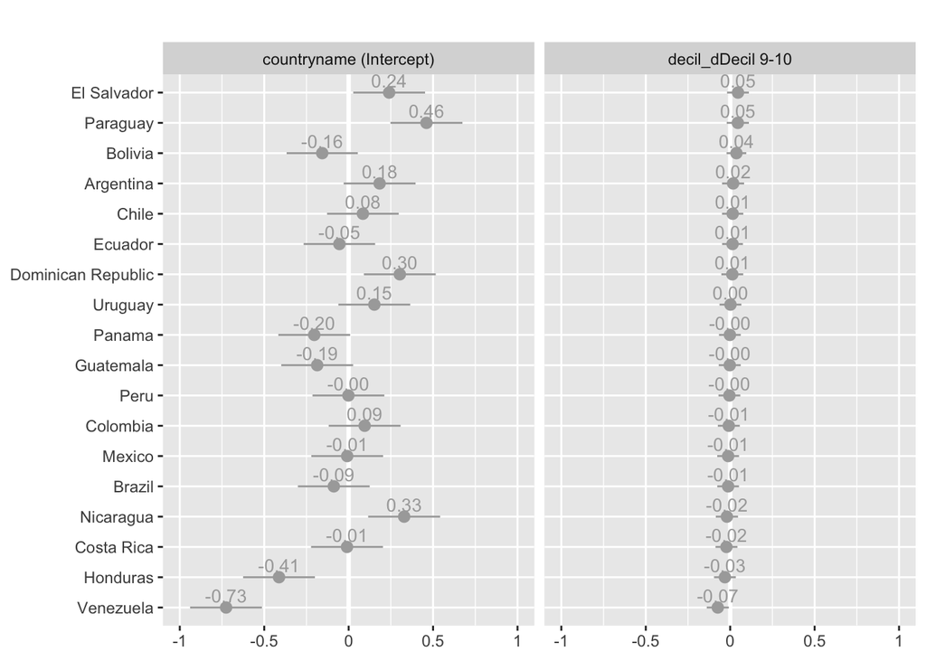

```r
#Figura 4: Random income effect on redistributive preference by country: intercept and slope (Model includes weight)
figure4=plot_model(model_w6, type = "re",
           show.legend = FALSE,
           show.values = TRUE,
           facet.grid = FALSE,
           y.offset = .4,
           value.offset = .4,
           value.size = 3.5,
           color="darkgray",
           sort.est= "decil_dDecil 9-10",
           title = " ",)
figure4
```

```r
ggsave("Graphs/Figure4.png", plot=figure4[[2]])
```

- Multilevel estimation: Figura 5. Marginal Effects

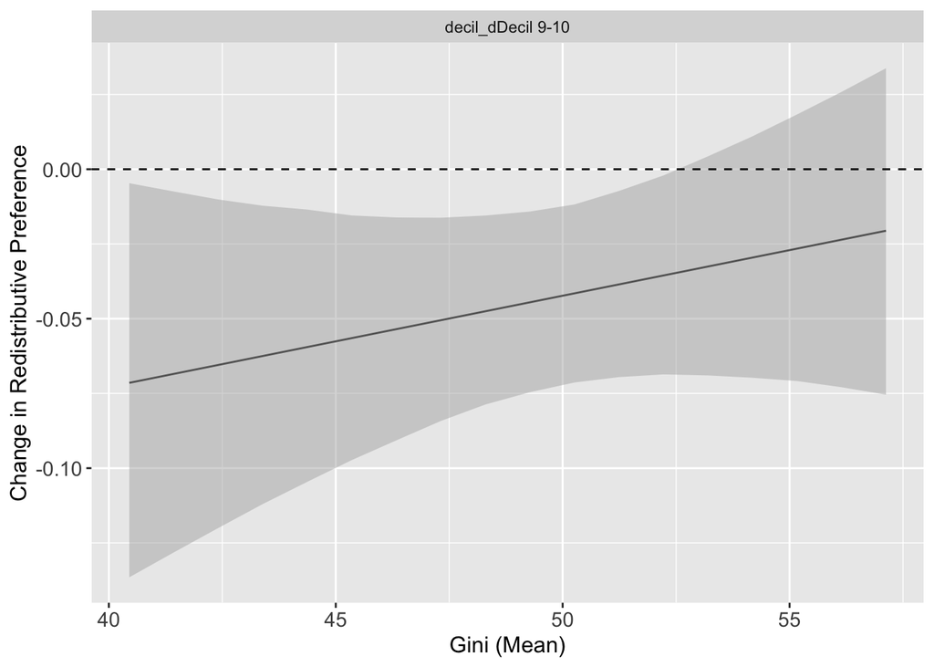

```r
#Figure 5: Marginal effects
#GINI (Mean)
figure5a = interplot(m = model_w7, var1 = 'decil_d', var2 = 'gini_mean', ci = 0.90) +
  xlab("Gini (Mean)") +
  ylab("Change in Redistributive Preference") +
  geom_hline(yintercept = 0, linetype = "dashed") +
  theme(axis.text=element_text(size=11),
        axis.title.y = element_text(size =12),
        axis.title.x = element_text(size = 12))
figure5a
```

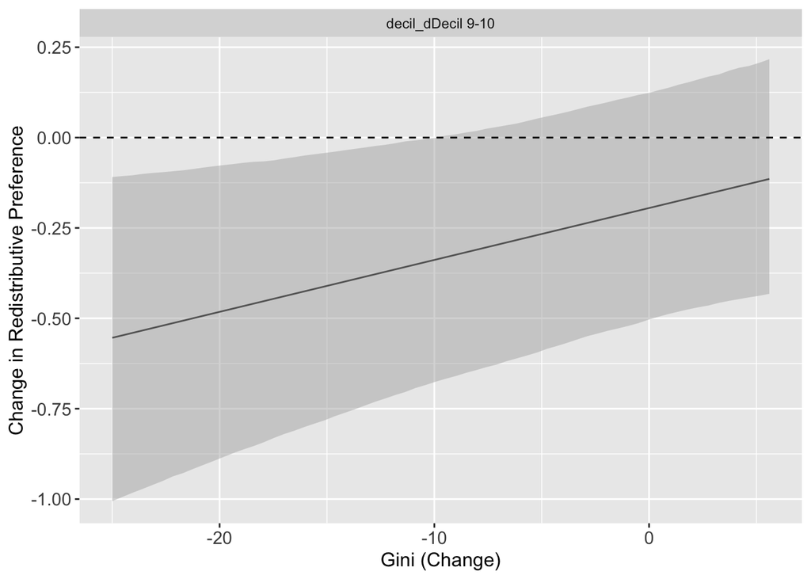

```r
ggsave("Graphs/Figure5a.png", plot=figure5a)

#GINI (Change)
figure5b = interplot(m = model_w7, var1 = 'decil_d', var2 = 'gini_dif', ci = 0.90, xmin=-25) +
  xlab("Gini (Change)") +
  ylab("Change in Redistributive Preference") +
  geom_hline(yintercept = 0, linetype = "dashed") +
  theme(axis.text=element_text(size=11),
        axis.title.y = element_text(size =12),
        axis.title.x = element_text(size = 12))
figure5b
```

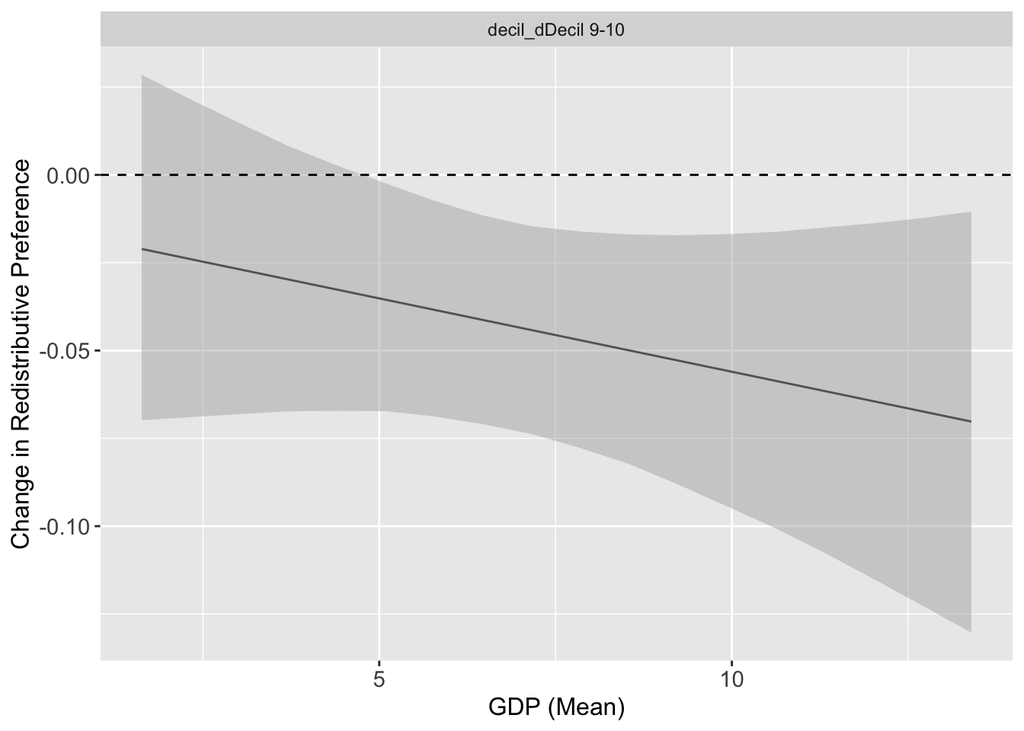

```r
ggsave("Graphs/Figure5b.png", plot=figure5b)

#GDP (Mean)
figure5c = interplot(m = model_w8, var1 = 'decil_d', var2 = 'gdp_mean', ci = 0.90) +
  xlab("GDP (Mean)") +
  ylab("Change in Redistributive Preference") +
  geom_hline(yintercept = 0, linetype = "dashed") +
  theme(axis.text=element_text(size=11),
        axis.title.y = element_text(size =12),
        axis.title.x = element_text(size = 12))
figure5c
```

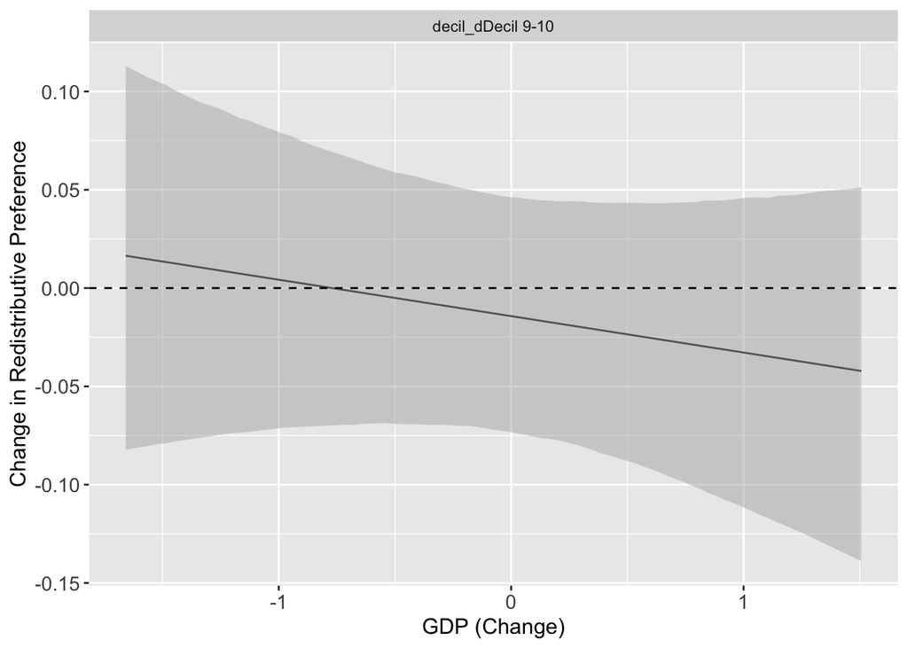

```r
ggsave("Graphs/Figure5c.png", plot=figure5c)
#GDP (Change)
figure5d = interplot(m = model_w8, var1 = 'decil_d', var2 = 'gdp_dif', ci = 0.90) +
  xlab("GDP (Change)") +
  ylab("Change in Redistributive Preference") +
  geom_hline(yintercept = 0, linetype = "dashed") +
  theme(axis.text=element_text(size=11),
        axis.title.y = element_text(size =12),
        axis.title.x = element_text(size = 12))
figure5d
```

```r
ggsave("Graphs/Figure5d.png", plot=figure5d)
```

- Tables and complementary figures (annex)

```r
#6.1# Table4: Sample: Observations by country and year
lapop1$cases=1
sample = with(lapop1, tapply(cases, list(countryname, year), sum))
sample = as.data.frame(sample)
sample$total <- rowSums(sample[c("2008", "2010", "2012", "2014")])
sample_country = as.data.frame(with(lapop1, tapply(cases, list(year), sum)))
xtable(sample, digits = 0)
```

```
## % latex table generated in R 3.5.1 by xtable 1.8-3 package
## % Fri Feb  1 10:52:12 2019
## \begin{table}[ht]
## \centering
## \begin{tabular}{rrrrrr}
##   \hline
##  & 2008 & 2010 & 2012 & 2014 & total \\
##   \hline
## Argentina & 1370 & 1340 & 1461 & 1378 & 5549 \\
##   Bolivia & 2854 & 2887 & 2910 & 3003 & 11654 \\
##   Brazil & 1332 & 2274 & 1439 & 1394 & 6439 \\
##   Chile & 1463 & 1903 & 1502 & 1489 & 6357 \\
##   Colombia & 1445 & 1470 & 1372 & 1462 & 5749 \\
##   Costa Rica & 1403 & 1443 & 1424 & 1502 & 5772 \\
##   Dominican Republic & 1389 & 1422 & 1453 & 1492 & 5756 \\
##   Ecuador & 2857 & 2934 & 1422 & 1415 & 8628 \\
##   El Salvador & 1512 & 1537 & 1373 & 1503 & 5925 \\
##   Guatemala & 1320 & 1372 & 1433 & 1379 & 5504 \\
##   Honduras & 1428 & 1555 & 1631 & 1520 & 6134 \\
##   Mexico & 1502 & 1523 & 1522 & 1471 & 6018 \\
##   Nicaragua & 1287 & 1348 & 1569 & 1471 & 5675 \\
##   Panama & 1471 & 1496 & 1554 & 1474 & 5995 \\
##   Paraguay & 1122 & 1449 & 1454 & 1443 & 5468 \\
##   Peru & 1452 & 1466 & 1475 & 1454 & 5847 \\
##   Uruguay & 1448 & 1462 & 1469 & 1490 & 5869 \\
##   Venezuela & 1209 & 1439 & 1376 & 1441 & 5465 \\
##    \hline
## \end{tabular}
## \end{table}
```

```r
xtable(sample_country, digits = 0)
```

```
## % latex table generated in R 3.5.1 by xtable 1.8-3 package
## % Fri Feb  1 10:52:12 2019
## \begin{table}[ht]
## \centering
## \begin{tabular}{rr}
##   \hline
##  & with(lapop1, tapply(cases, list(year), sum)) \\
##   \hline
## 2008 & 27864 \\
##   2010 & 30320 \\
##   2012 & 27839 \\
##   2014 & 27781 \\
##    \hline
## \end{tabular}
## \end{table}
```

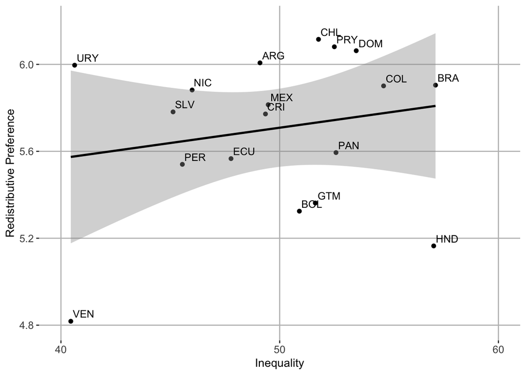

```r
#6.3#Inequality: Relationship "between" countries
between = aggregate(lapop1, by=list(lapop1$country), FUN=mean, na.rm=TRUE)
figure63= ggplot(between,
            aes(x= gini_mean, y= redistribution, label=Group.1)) +
  geom_point() +
  geom_smooth(method = "lm", colour="black") +
  geom_text(aes(label=Group.1),hjust=-0.1, vjust=-0.5, size=3.5) +
  labs(x = "Inequality", y = "Redistributive Preference", fill="") +
  scale_y_continuous("Redistributive Preference", limits = c(4.8,6.2),
                     breaks = c(4.8,5.2,5.6,6)) +
  scale_x_continuous("Inequality", limits = c(40,60),
                     breaks = c(40,50,60)) +
  theme(panel.grid.major = element_line(colour = "grey"),
        legend.position="none",
        axis.text=element_text(size=10),
        strip.text=element_text(size=12),
        legend.text=element_text(size=12),
        legend.title=element_text(size=12),
        legend.key.size=unit(1,"cm"),
        panel.background = element_rect(fill = "white"))
figure63
```

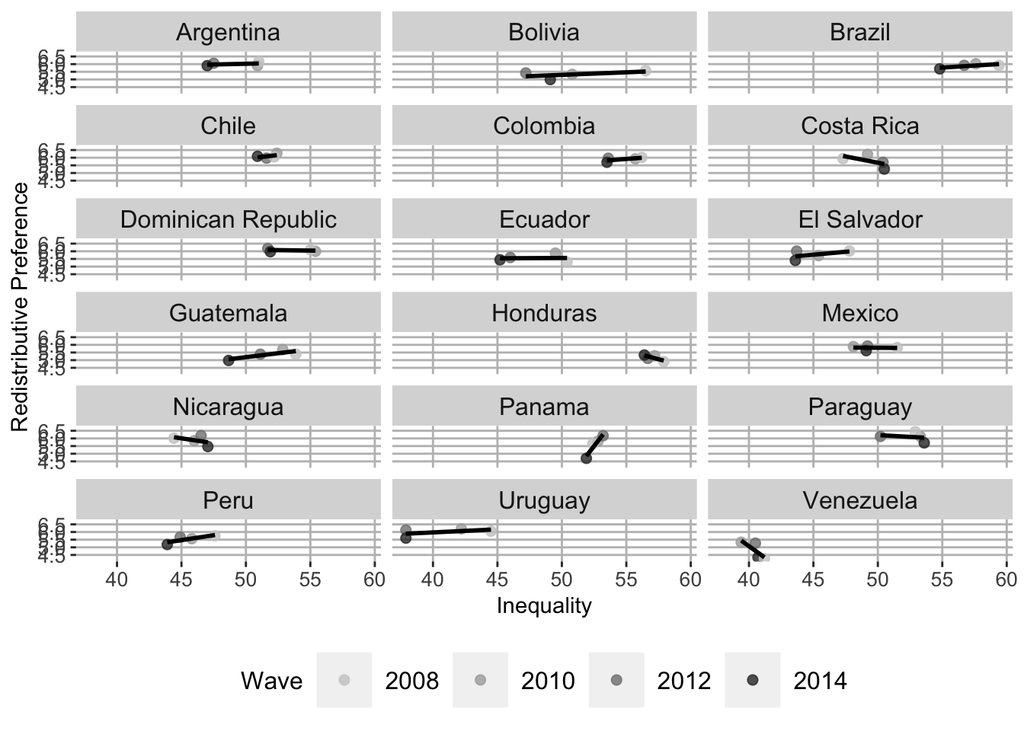

```r
ggsave("Graphs/Figure63.png", plot=figure63)

#6.4#Inequality: Relationship "within" countries
figure64= ggplot(lapop_country_year1,
            aes(x= gini, y= redistribution, colour=as.factor(wave+2000))) +
  geom_point(size = 2, alpha = .8) +
  stat_smooth(size = 1, method = "lm", se = FALSE, colour="black") +
  facet_wrap(~countryname, ncol=3) +
  labs(x = "Inequality", y =  "Redistributive Preference") +
  scale_color_grey(start=0.8, end=0.2, name="Wave") +
  scale_y_continuous( "Redistributive Preference", limits = c(4.2,6.7),
                     breaks = c(4.5,5,5.5,6,6.5)) +
  scale_x_continuous("Inequality",
                     breaks = c(35,40,45,50,55,60)) +
  theme(panel.grid.major = element_line(colour = "grey"),
        legend.position="bottom",
        axis.text=element_text(size=10),
        strip.text=element_text(size=12),
        legend.text=element_text(size=12),
        legend.title=element_text(size=12),
        legend.key.size=unit(1,"cm"),
        panel.background = element_rect(fill = "white"))
figure64
```

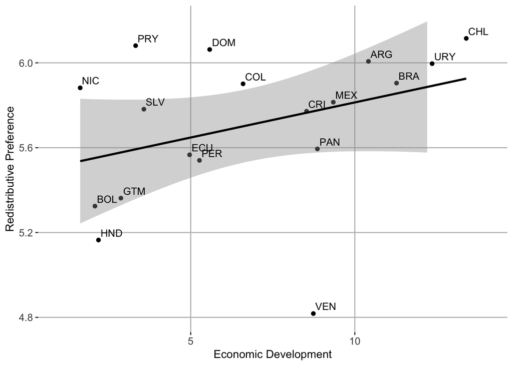

```r
ggsave("Graphs/Figure64.png", plot=figure64, height = 10, width = 10, units="in")

#6.5#Economic Development: Relationship "between" countries
figure65 = ggplot(between,
            aes(x= gdp_mean, y= redistribution, label=Group.1)) +
  geom_point() +
  geom_smooth(method = "lm", colour="black") +
  geom_text(aes(label=Group.1),hjust=-0.1, vjust=-0.5, size=3.5) +
  labs(x = "Economic Development", y = "Redistributive Preference", fill="") +
  scale_y_continuous("Redistributive Preference", limits = c(4.8,6.2),
                     breaks = c(4.8,5.2,5.6,6)) +
  scale_x_continuous("Economic Development", limits = c(1,14),
                     breaks = c(5,10,15)) +
  theme(panel.grid.major = element_line(colour = "grey"),
        legend.position="none",
        axis.text=element_text(size=10),
        strip.text=element_text(size=12),
        legend.text=element_text(size=12),
        legend.title=element_text(size=12),
        legend.key.size=unit(1,"cm"),
        panel.background = element_rect(fill = "white"))
figure65
```

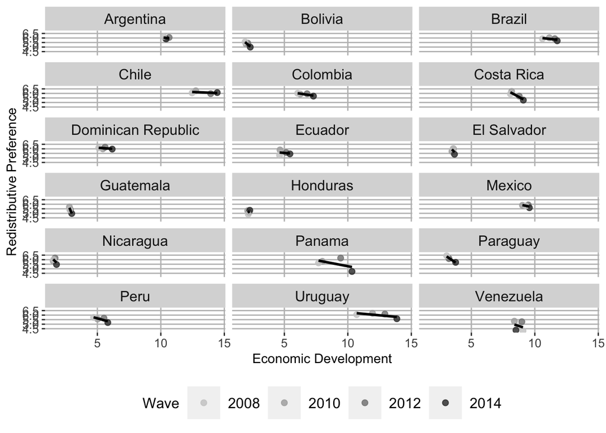

```r
ggsave("Graphs/Figure65.png")

#6.6#Economic Development: Relationship "within" countries
figure66= ggplot(lapop_country_year1,
            aes(x= gdp, y= redistribution, colour=as.factor(wave+2000))) +
  geom_point(size = 2, alpha = .8) +
  stat_smooth(size = 1, method = "lm", se = FALSE, colour="black") +
  facet_wrap(~countryname, ncol=3) +
  labs(x = "Economic Development", y =  "Redistributive Preference") +
  scale_color_grey(start=0.8, end=0.2, name="Wave") +
  scale_y_continuous( "Redistributive Preference", limits = c(4.2,6.7),
                     breaks = c(4.5,5,5.5,6,6.5)) +
  scale_x_continuous("Economic Development",
                     breaks = c(0,5,10,15,20)) +
  theme(panel.grid.major = element_line(colour = "grey"),
        legend.position="bottom",
        axis.text=element_text(size=10),
        strip.text=element_text(size=12),
        legend.text=element_text(size=12),
        legend.title=element_text(size=12),
        legend.key.size=unit(1,"cm"),
        panel.background = element_rect(fill = "white"))
figure66
```

```r
ggsave("Graphs/Figure66.png", plot=figure66, height = 10, width = 10, units="in")
```